title: “st542_project10” author: “Annie Brinza, Jingjing Li, Nicole Levin” date: “2023-06-15” output: pdf_document: default html_document: default —

```r
library(tidyverse)
```

```r
library(ggplot2)
library(haven)
library(tidyverse)
library(ggplot2)
library(haven)
library(psych)
```

### Exploring the merged data

```r
survey_merged <- read_dta("../data/merged_survey_panel96_19_noID.dta")
dim(survey_merged)
```

```
## [1] 55734   165
```

```r
survey_merged_clean <- survey_merged %>%
  filter(!is.na(lotid_qualtrics))
# Removing duplicates for modelling - forgot to ask Mariana which should be kept, so just keeping first for now
# Also open to just dropping all duplicated lotids - there's only 42
survey_final <- survey_merged_clean %>% distinct(lotid_qualtrics, .keep_all = TRUE)
```

Now to check for nulls in columns:

```r
missing_vals <- survey_final %>% summarise_all(~sum(is.na(.)))
t(missing_vals)
```

```
##                       [,1]
## technician_times      2284
## family                1026
## north                 1026
## northeast             1026
## southeast             1026
## south                 1026
## lotid_qualtrics          0
## studycode             1026
## havecattle            1131
## havecattleother       1147
## cattleherd            1184
## cattlemilk            1152
## milkhardry            1651
## milkharwet            1651
## milkhardry_min_dairy  1167
## milkharwet_max_dairy  1166
## pmilkdrynominal       1825
## pmilkwetnominal       1771
## milkincwet            1226
## milkincdry            1226
## irrigation_pas        2251
## drought_year          2032
## risk                  1086
## annual_crops          1026
## perennial_crops       1026
## incbeef               1577
## cattle_price          2150
## incpension            1058
## incbolsafam           1058
## incoff                1182
## lotprice              1098
## housecity             1026
## keep_veg              1026
## soiltype_sand         1194
## soiltype_silt         1194
## soiltype_clay         1194
## soiltype_other        1194
## soiltype_dontknow     1194
## fishtanks_year        2062
```

[output cut: 111 more lines]

```
## SPI_nov               1026
## SPI_dec               1026
## off_farm              1182
## unions_part           1026
## cleared_area          1029
## cleared_area_fraction 1029
## Drainage_AreaKM_Ari   1970
## ARIQ_drainage         1017
## OPO_area_km           1869
## OPO_drainage           982
## RO_area_km            1858
## C                     2347
## Rolim_drainage         886
## lotsize_GIS_ponds        0
## ponds_2019               0
```

There seem to be a lot of columns missing 1026 values, which puts the numbers back to what we saw in the original data. Clearly there is a lot of missing data across all areas, so I don’t think we should drop all rows missing data.

## Feature Engineering

### Creating One Drainage Area Column

I will create one drainage area column, and then will drop all rows that don’t have drainage area. Not sure if this is the best approach but this data is so messy!

```r
# There are two lots that have areas in each region - will drop them
duplicate_regions <- survey_final %>% filter(!is.na(OPO_area_km) & !is.na(RO_area_km)) %>% select(lotid_qualtrics)
survey_final <- survey_final %>% filter(!(lotid_qualtrics %in% duplicate_regions$lotid_qualtrics))
survey_final <- survey_final %>% mutate(drainage_area_km = ifelse(!is.na(Drainage_AreaKM_Ari), Drainage_AreaKM_Ari, ifelse(!is.na(OPO_area_km), OPO_area_km, ifelse(!is.na(RO_area_km), RO_area_km, NA))),
                                        region = ifelse(studycode == 1, "Ariquemes",
                                                        ifelse(studycode == 2, "Ouro Preto do Oeste", ifelse(studycode == 3, "Rolim de Moura", NA)))) %>%
  select(-c(Drainage_AreaKM_Ari, RO_area_km, OPO_area_km))
```

### Creating Individual Adaptation Method Booleans

First, I need to create the indivdual adaptation method booleans i.e. `cattle_management` if the farmer employed any cattle management strategy. Then I can combine these to make a general adaptation method boolean.

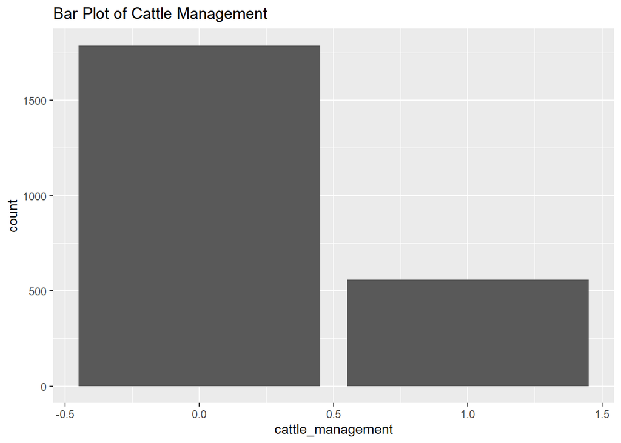

```r
survey_final <- survey_final %>% mutate(cattle_management = case_when(feed_cattle == 1  | soil_analysis == 1 | cattleinputs_breed == 1 | semiconfine == 1 | sellcattle_droughtexp == 1 ~ 1, .default = 0),
                                        pasture_management = case_when(irrigation_pas == 1 | pasture_productivity == 1 | fert_pasture ==1 | pest_pasture == 1 | fallow == 1 ~ 1, .default = 0),
                                        forest_conservation = case_when(forest_rec == 1 | keep_veg == 1 ~ 1, .default = 0),
                                        water_management = case_when(waterstructure == 1 | well_have == 1 | dam_have == 1 | reservoir_have == 1 ~ 1, .default = 0)) # Chose to use case when to account for NA - need to ask Mariana how these should be treated

# Looking at distributions
g <- ggplot(data = survey_final, aes(x = cattle_management))
g + geom_bar() + labs(title = "Bar Plot of Cattle Management")
```

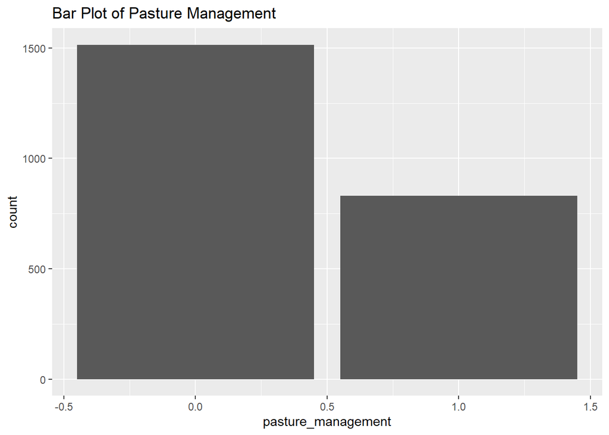

```r
g <- ggplot(data = survey_final, aes(x = pasture_management))
g + geom_bar() + labs(title = "Bar Plot of Pasture Management")
```

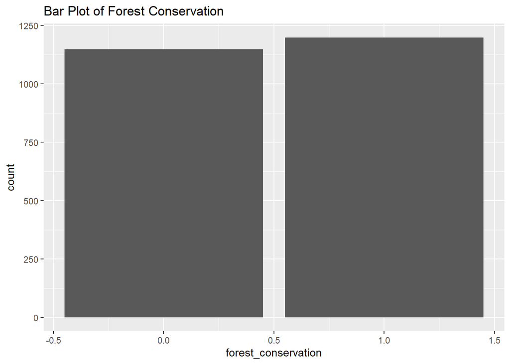

```r
g <- ggplot(data = survey_final, aes(x = forest_conservation))
g + geom_bar() + labs(title = "Bar Plot of Forest Conservation")
```

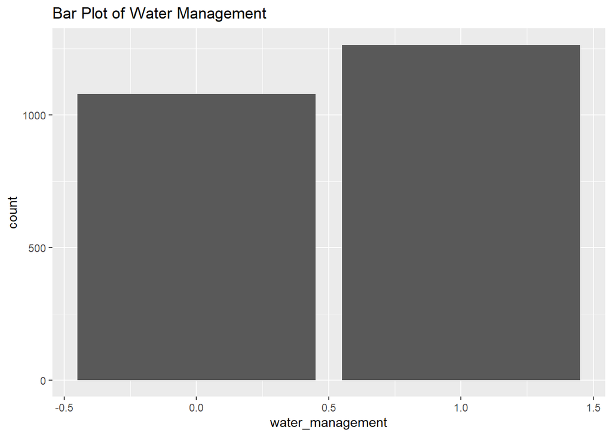

```r
g <- ggplot(data = survey_final, aes(x = water_management))
g + geom_bar() + labs(title = "Bar Plot of Water Management")
```

### Creating General Adaptation Method Boolean

Now that the indivdual adaptation measures have been created, I will create a general adaptation method boolean

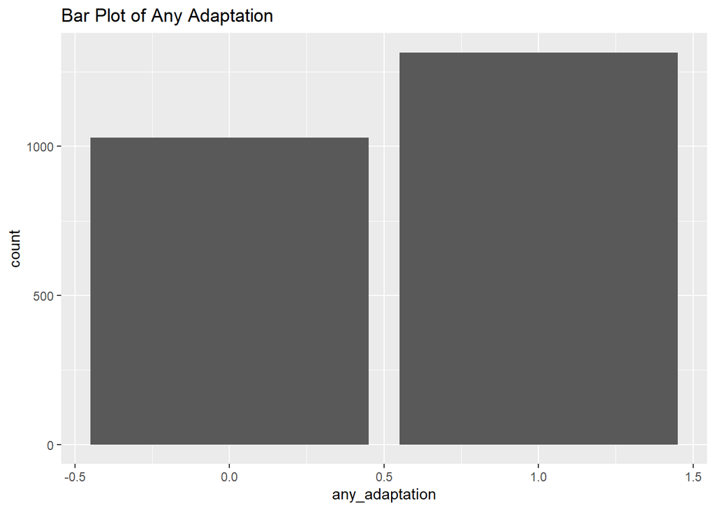

```r
survey_final <- survey_final %>% mutate(any_adaptation = ifelse(cattle_management == 1 | pasture_management == 1 | forest_conservation == 1 | water_management == 1,1,0))

# Looking at the distribution
g <- ggplot(data = survey_final, aes(x = any_adaptation))
g + geom_bar() + labs(title = "Bar Plot of Any Adaptation")
```

Not a fully even data set, but better balanced than I predicted it would be. I don’t think rebalancing is needed for the final analysis.

Now let’s see if we remove farmers who don’t have GIS information

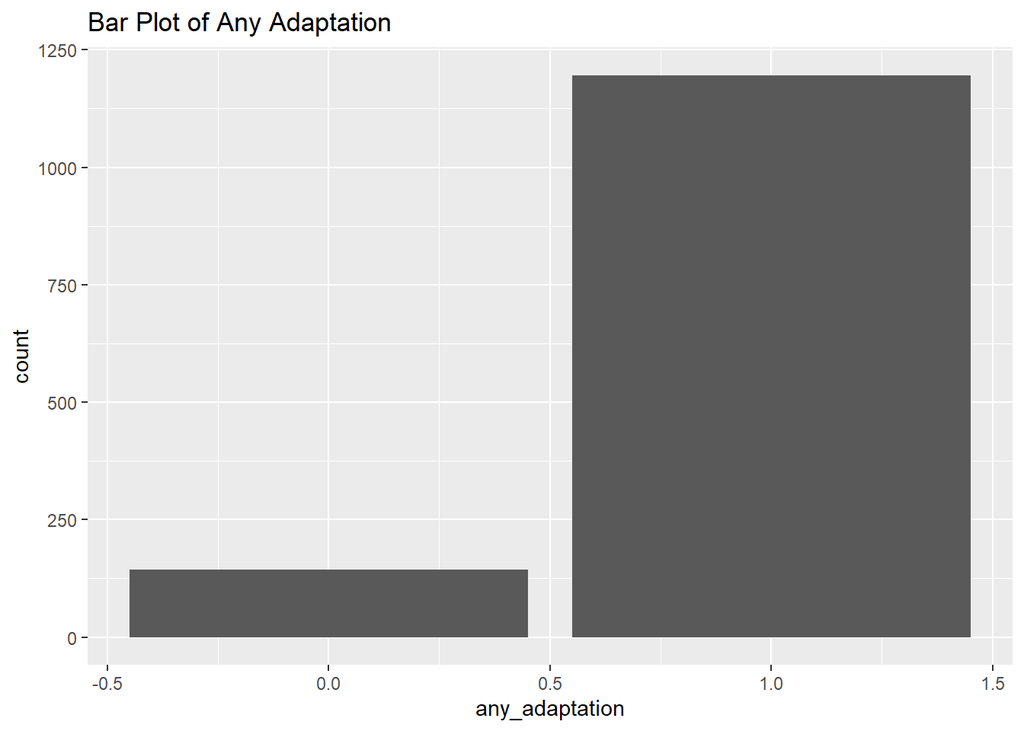

```r
survey_final_gis <- survey_final %>% filter(!is.na(drainage_area_km))

# Looking at the distribution
g <- ggplot(data = survey_final_gis, aes(x = any_adaptation))
g + geom_bar() + labs(title = "Bar Plot of Any Adaptation")
```

Now it is very imbalanced. Not as horrible as it could be - but could affect the outputs of the model. Is SPI still missing for these?

```r
missing_vals_gis <- survey_final_gis %>% summarise_all(~sum(is.na(.)))
t(missing_vals_gis)
```

```
##                       [,1]
## technician_times      1280
## family                 140
## north                  140
## northeast              140
## southeast              140
## south                  140
## lotid_qualtrics          0
## studycode              140
## havecattle             234
## havecattleother        247
## cattleherd             276
## cattlemilk             249
## milkhardry             725
## milkharwet             725
## milkhardry_min_dairy   262
## milkharwet_max_dairy   262
## pmilkdrynominal        858
## pmilkwetnominal        807
## milkincwet             320
## milkincdry             320
## irrigation_pas        1262
## drought_year          1051
## risk                   194
## annual_crops           140
## perennial_crops        140
## incbeef                642
## cattle_price          1162
## incpension             168
## incbolsafam            168
## incoff                 284
## lotprice               203
## housecity              140
## keep_veg               140
## soiltype_sand          293
## soiltype_silt          293
## soiltype_clay          293
## soiltype_other         293
## soiltype_dontknow      293
## fishtanks_year        1093
```

[output cut: 115 more lines]

```
## cleared_area           143
## cleared_area_fraction  143
## ARIQ_drainage          131
## OPO_drainage            96
## C                     1340
## Rolim_drainage           0
## lotsize_GIS_ponds        0
## ponds_2019               0
## drainage_area_km         0
## region                 140
## cattle_management        0
## pasture_management       0
## forest_conservation      0
## water_management         0
## any_adaptation           0
```

Now only for 140 of them, who are also missing region. Let’s drop those and see:

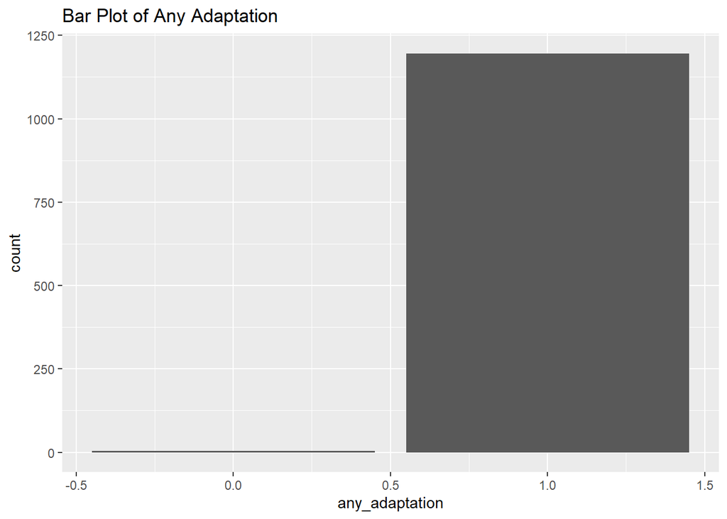

```r
survey_final_gis_clean <- survey_final_gis %>% filter(!is.na(SPImin_year))

# Looking at the distribution
g <- ggplot(data = survey_final_gis_clean, aes(x = any_adaptation))
g + geom_bar() + labs(title = "Bar Plot of Any Adaptation")
```

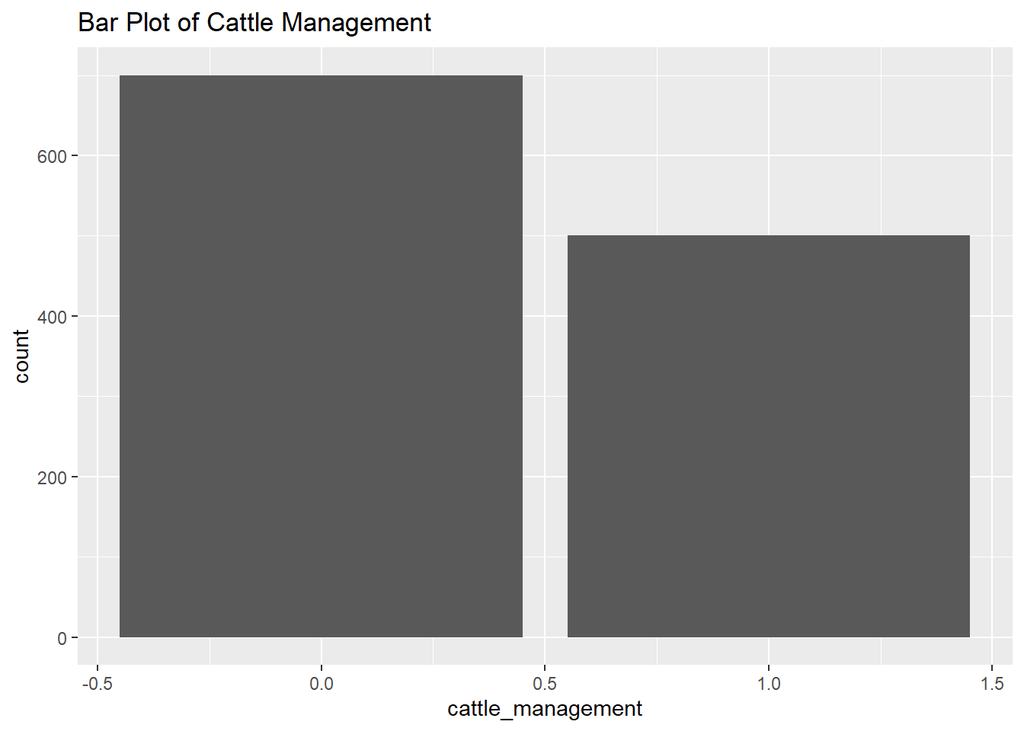

```r
# Looking at the distribution for the individual variables
g <- ggplot(data = survey_final_gis_clean, aes(x = cattle_management))
g + geom_bar() + labs(title = "Bar Plot of Cattle Management")
```

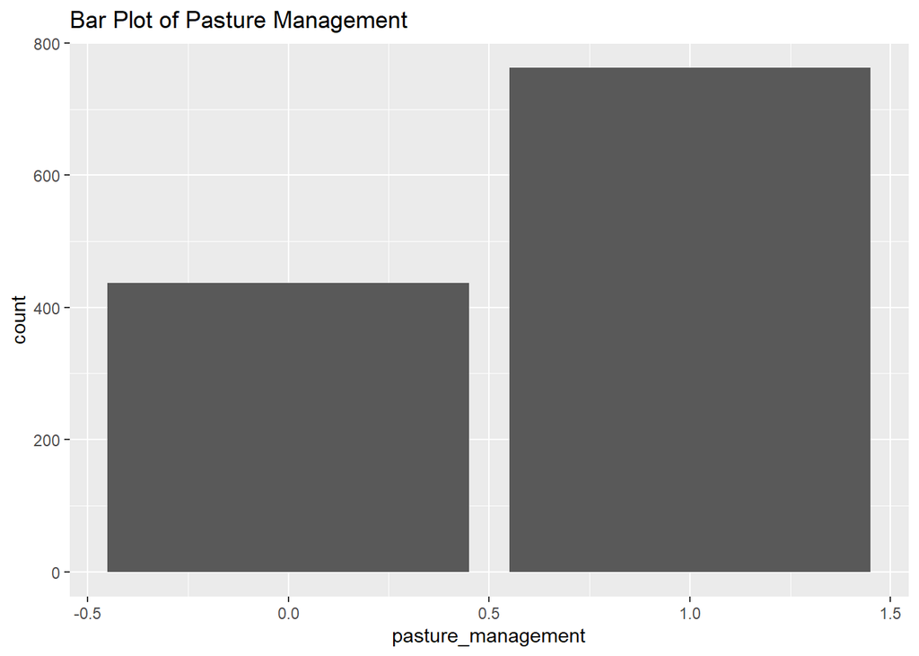

```r
g <- ggplot(data = survey_final_gis_clean, aes(x = pasture_management))
g + geom_bar() + labs(title = "Bar Plot of Pasture Management")
```

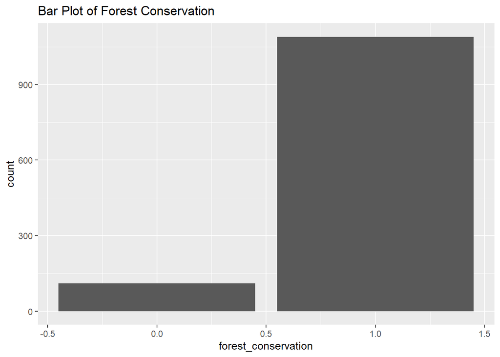

```r
g <- ggplot(data = survey_final_gis_clean, aes(x = forest_conservation))
g + geom_bar() + labs(title = "Bar Plot of Forest Conservation")
```

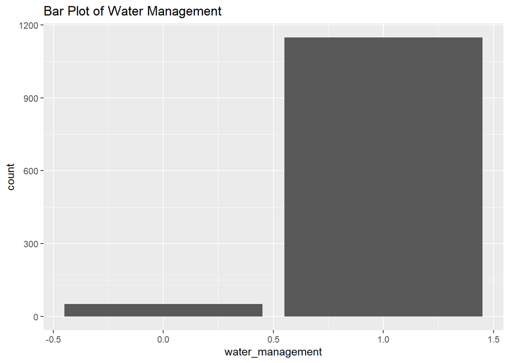

```r
g <- ggplot(data = survey_final_gis_clean, aes(x = water_management))
g + geom_bar() + labs(title = "Bar Plot of Water Management")
```

And everyone did some sort of adaptation method. Great - this means if we drop all missing water data, we can’t look at a relationship between general adaptation and results. If we include rows that are missing SPI and just use drainage area, there is still a model that can be run.

## Exploratory Data Analysis

Start EDA with some individual variable histograms.

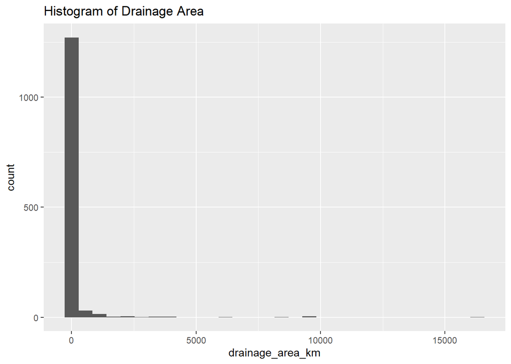

```r
g <- ggplot(data = survey_final_gis, aes(x = drainage_area_km))
g + geom_histogram() + labs(title = "Histogram of Drainage Area")
```

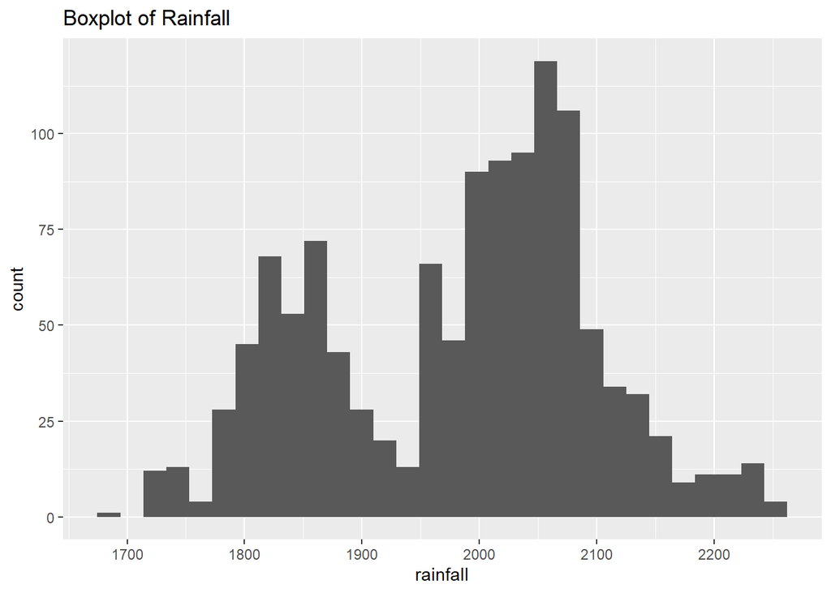

```r
g <- ggplot(data = survey_final_gis, aes(x = rainfall))
g + geom_histogram() + labs(title = "Boxplot of Rainfall")
```

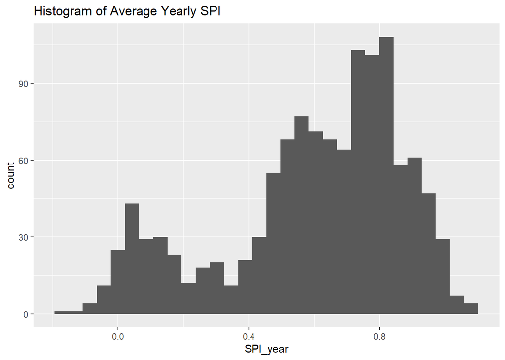

```r
g <- ggplot(data = survey_final_gis, aes(x = SPI_year))
g + geom_histogram() + labs(title = "Histogram of Average Yearly SPI")
```

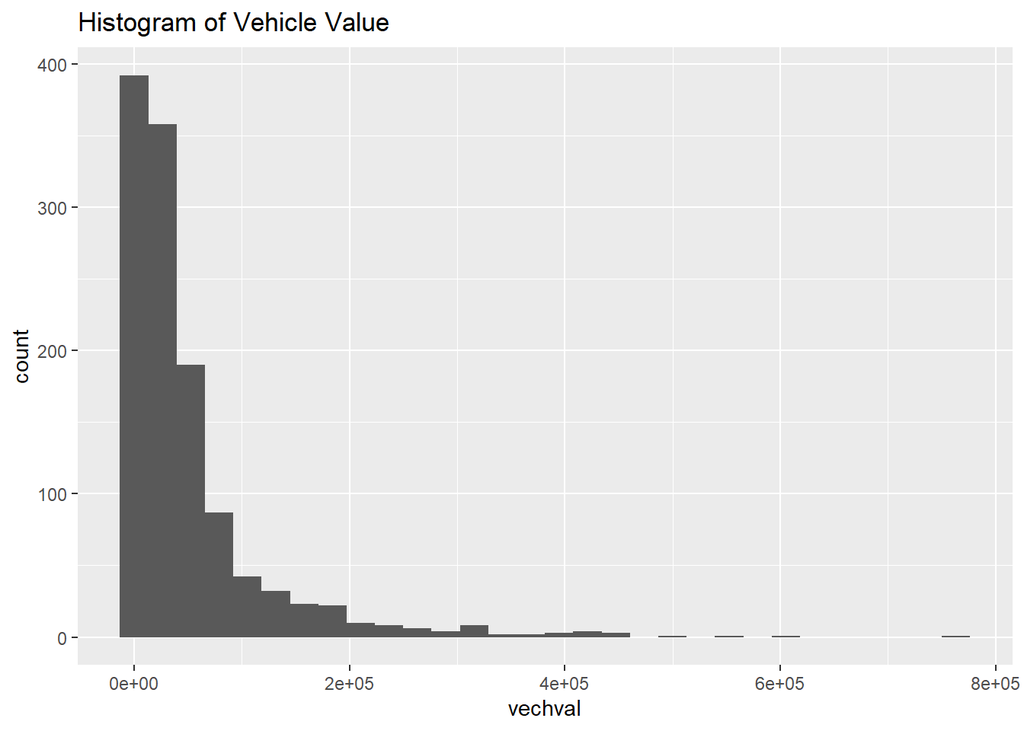

```r
g <- ggplot(data = survey_final_gis, aes(x = vechval))
g + geom_histogram() + labs(title = "Histogram of Vehicle Value")
```

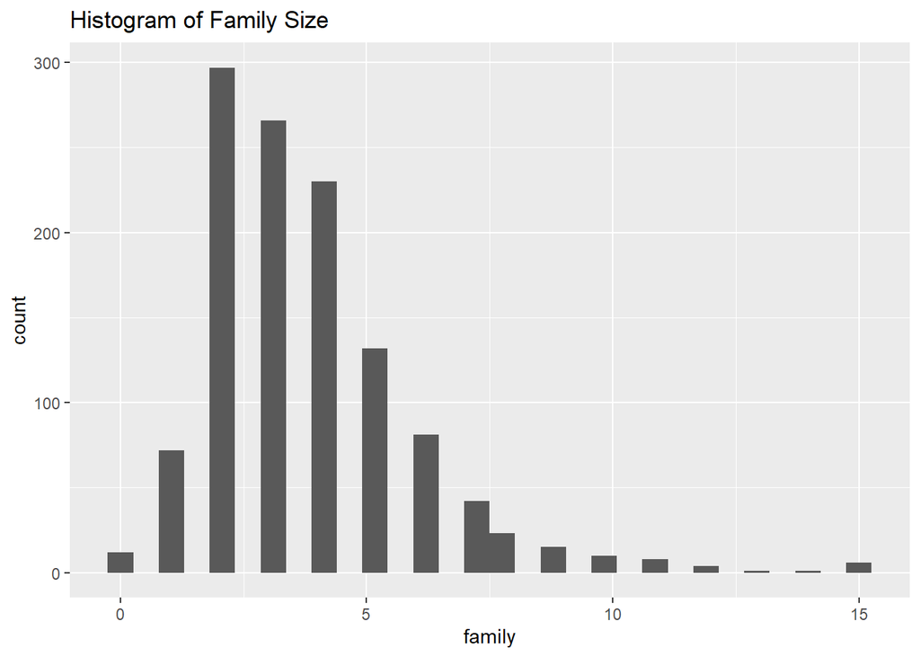

```r
g <- ggplot(data = survey_final_gis, aes(x = family))
g + geom_histogram() + labs(title = "Histogram of Family Size")
```

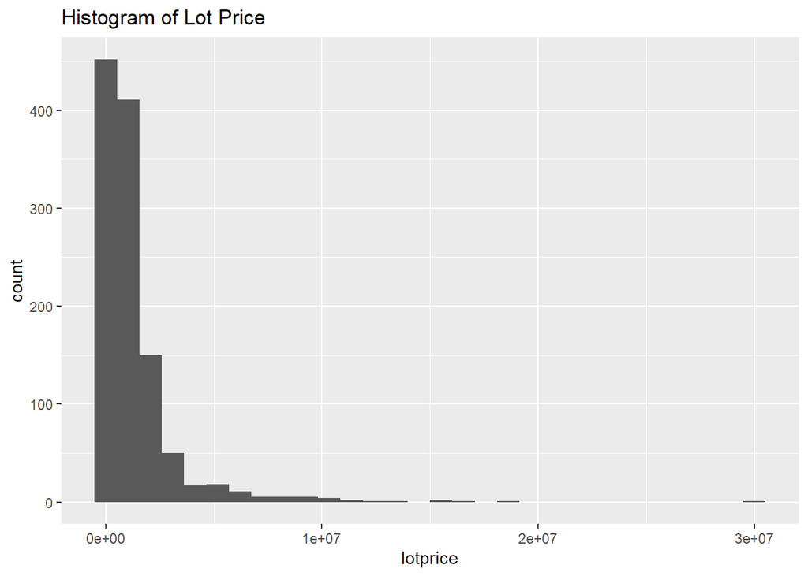

```r
g <- ggplot(data = survey_final_gis, aes(x = lotprice))
g + geom_histogram() + labs(title = "Histogram of Lot Price")
```

Next, we can look at some box plots

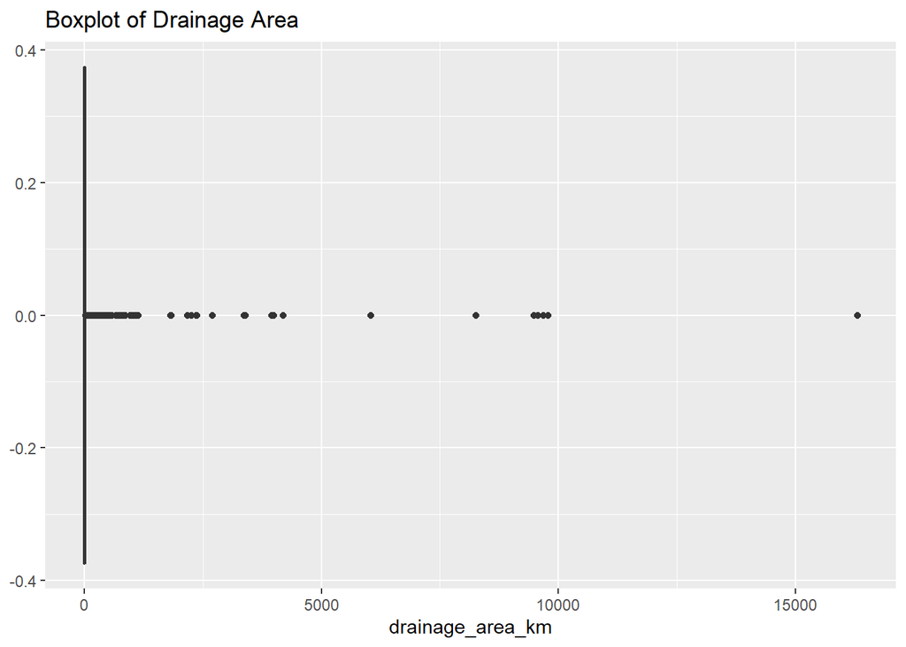

```r
g <- ggplot(data = survey_final_gis, aes(x = drainage_area_km))
g + geom_boxplot() + labs(title = "Boxplot of Drainage Area")
```

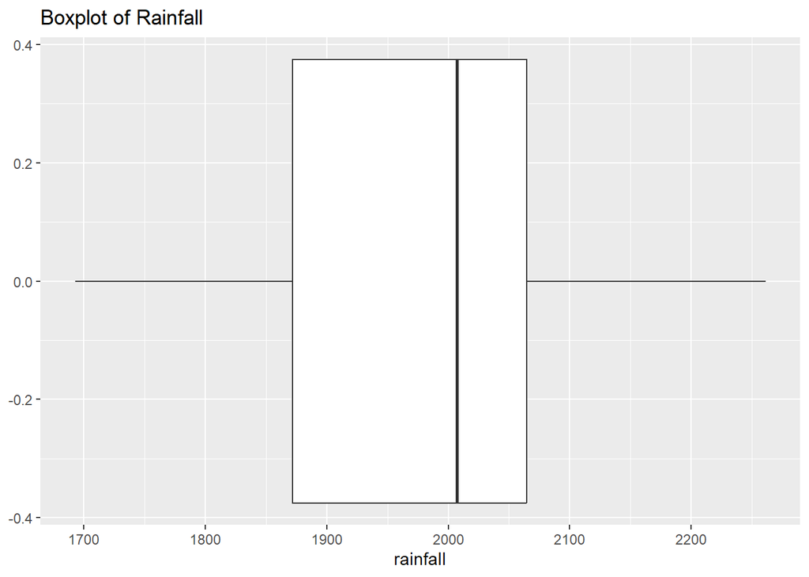

```r
g <- ggplot(data = survey_final_gis, aes(x = rainfall))
g + geom_boxplot() + labs(title = "Boxplot of Rainfall")
```

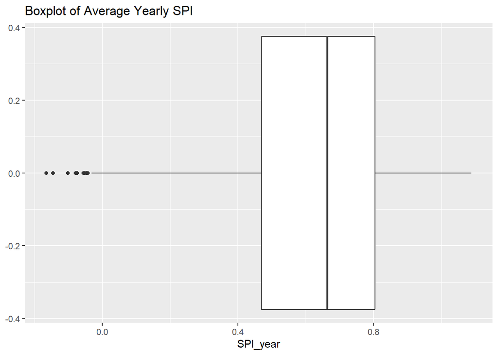

```r
g <- ggplot(data = survey_final_gis, aes(x = SPI_year))
g + geom_boxplot() + labs(title = "Boxplot of Average Yearly SPI")
```

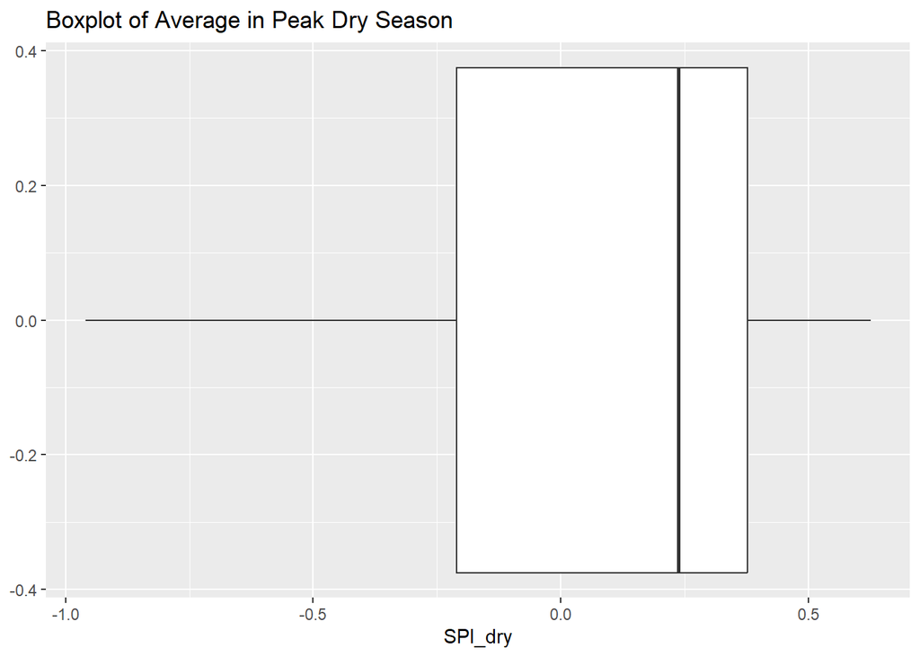

```r
g <- ggplot(data = survey_final_gis, aes(x = SPI_dry))
g + geom_boxplot() + labs(title = "Boxplot of Average in Peak Dry Season")
```

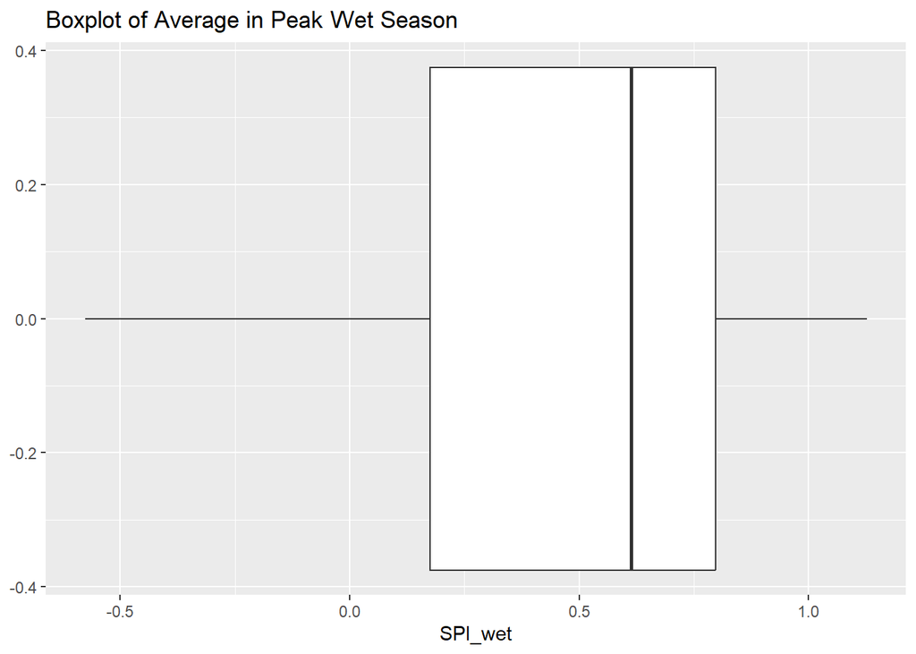

```r
g <- ggplot(data = survey_final_gis, aes(x = SPI_wet))
g + geom_boxplot() + labs(title = "Boxplot of Average in Peak Wet Season")
```

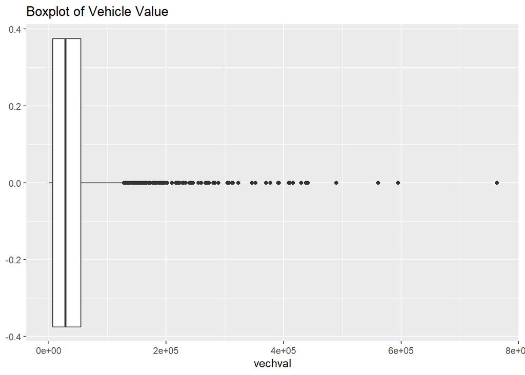

```r
g <- ggplot(data = survey_final_gis, aes(x = vechval))
g + geom_boxplot() + labs(title = "Boxplot of Vehicle Value")
```

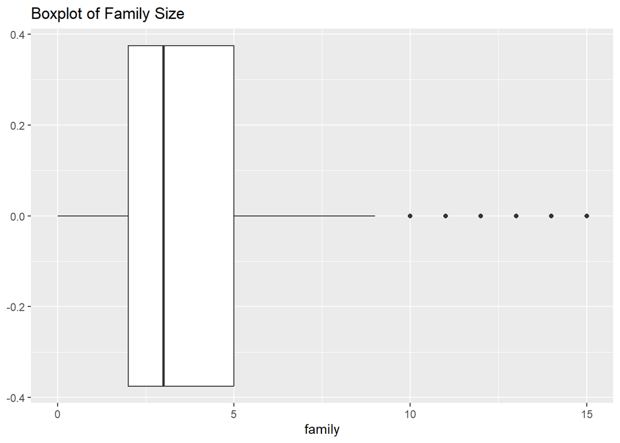

```r
g <- ggplot(data = survey_final_gis, aes(x = family))
g + geom_boxplot() + labs(title = "Boxplot of Family Size")
```

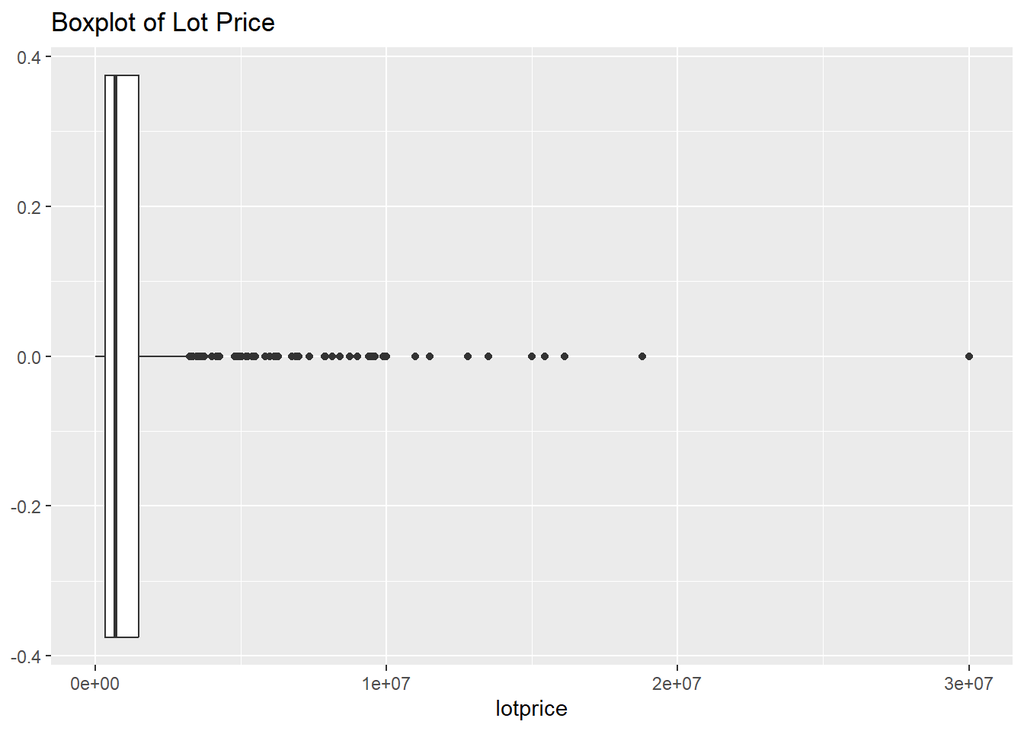

```r
g <- ggplot(data = survey_final_gis, aes(x = lotprice))
g + geom_boxplot() + labs(title = "Boxplot of Lot Price")
```

Let’s look at boxplots of drainage area and vehicle value (wealth) grouped by cattle.

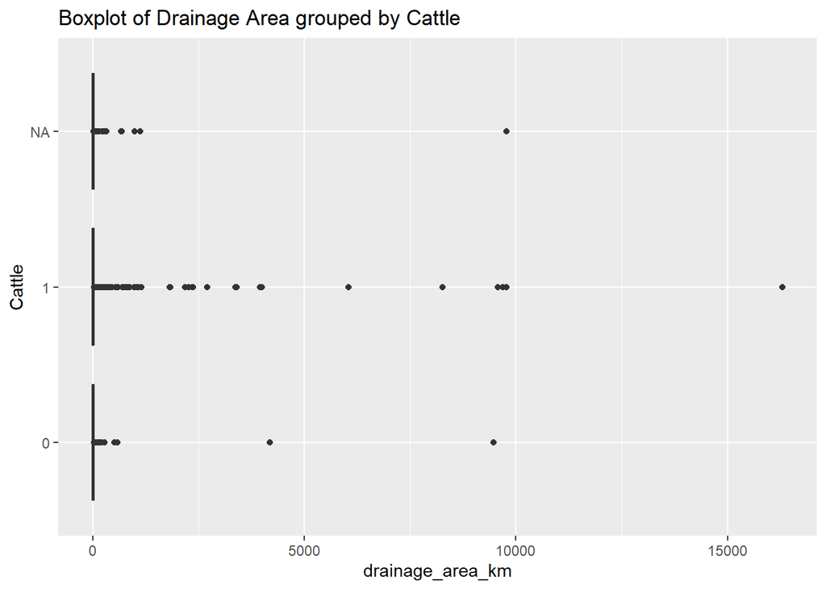

```r
g <- ggplot(data = survey_final_gis, aes(x = drainage_area_km, y = as.factor(havecattle)))
g + geom_boxplot() + labs(title = "Boxplot of Drainage Area grouped by Cattle") +
  ylab("Cattle")
```

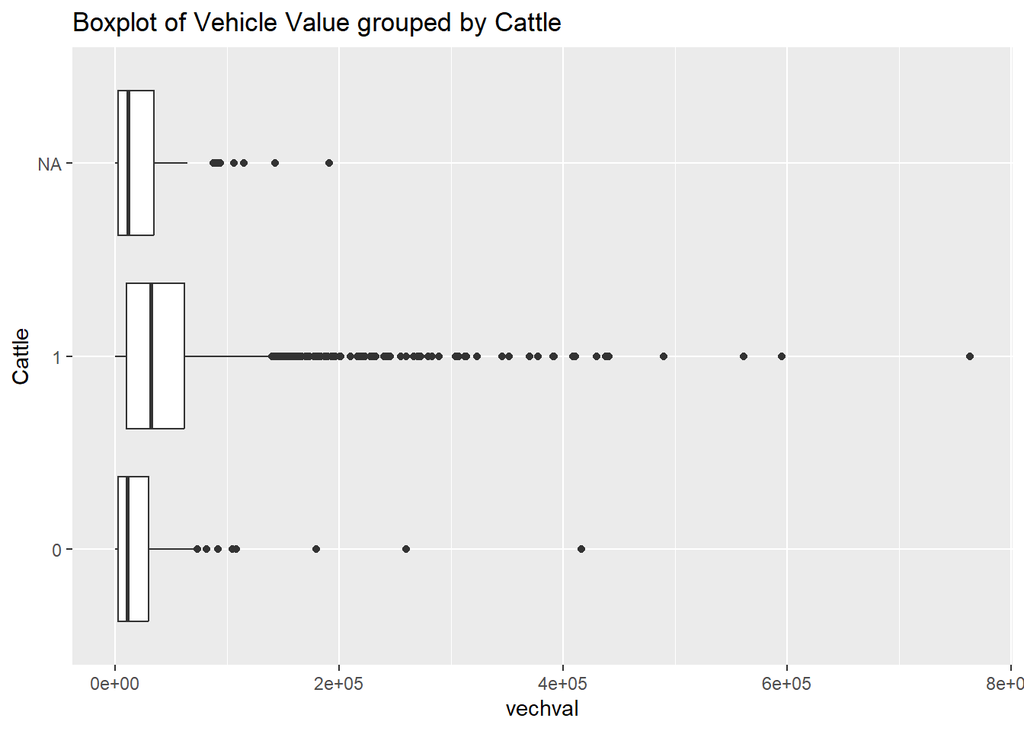

```r
g <- ggplot(data = survey_final_gis, aes(x = vechval, y = as.factor(havecattle)))
g + geom_boxplot() + labs(title = "Boxplot of Vehicle Value grouped by Cattle") +
  ylab("Cattle")
```

Let’s look at a few box plots split by region

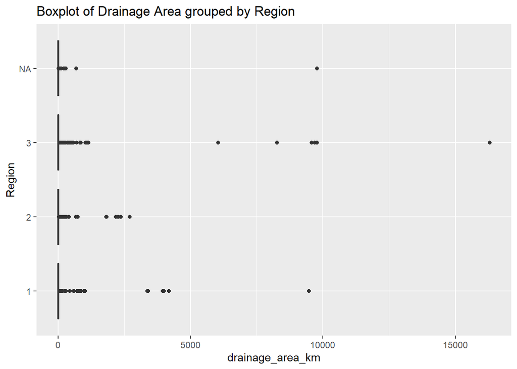

```r
g <- ggplot(data = survey_final_gis, aes(x = drainage_area_km, y = as.factor(studycode)))
g + geom_boxplot() + labs(title = "Boxplot of Drainage Area grouped by Region") +
  ylab("Region")
```

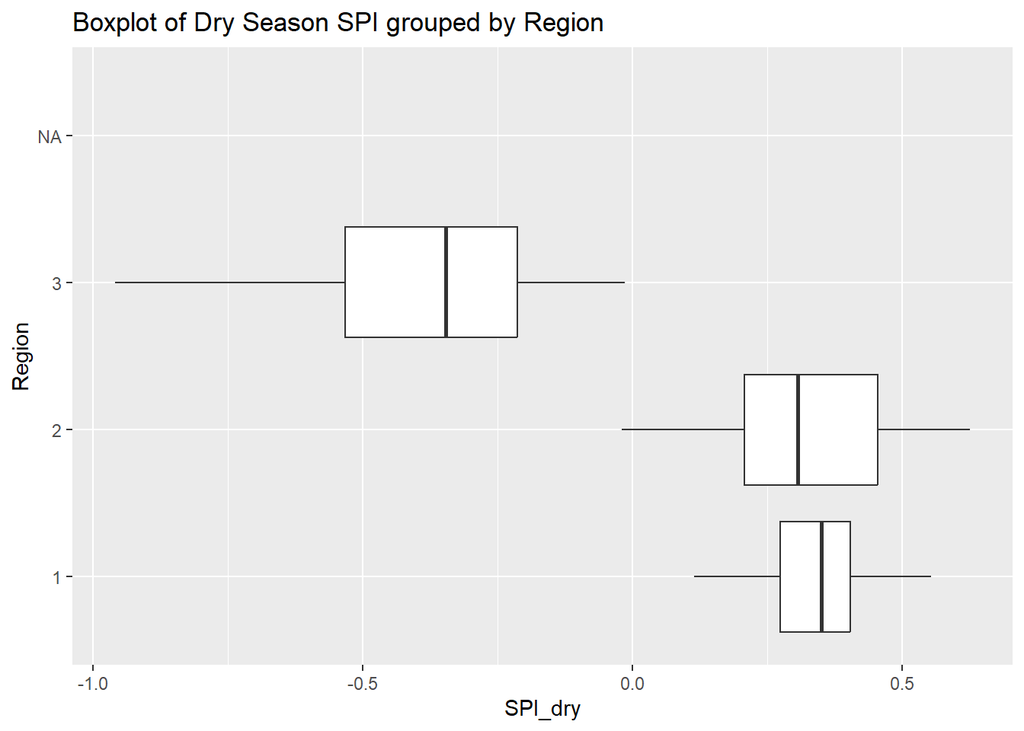

```r
g <- ggplot(data = survey_final_gis, aes(x = SPI_dry, y = as.factor(studycode)))
g + geom_boxplot() + labs(title = "Boxplot of Dry Season SPI grouped by Region") +
  ylab("Region")
```

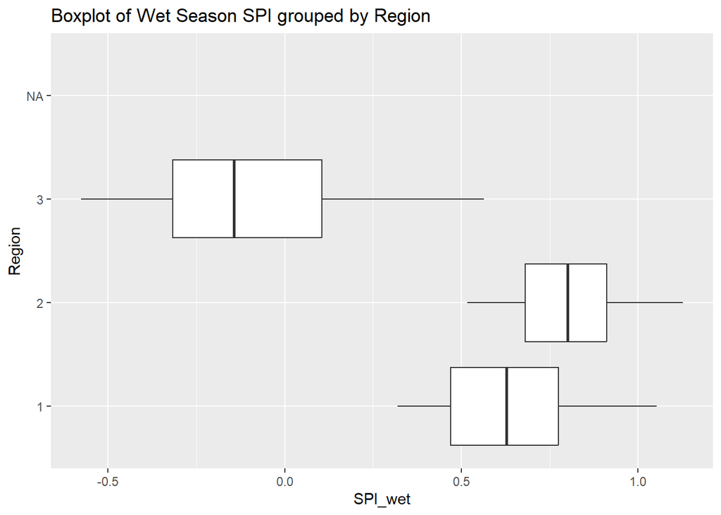

```r
g <- ggplot(data = survey_final_gis, aes(x = SPI_wet, y = as.factor(studycode)))
g + geom_boxplot() + labs(title = "Boxplot of Wet Season SPI grouped by Region") +
  ylab("Region")
```

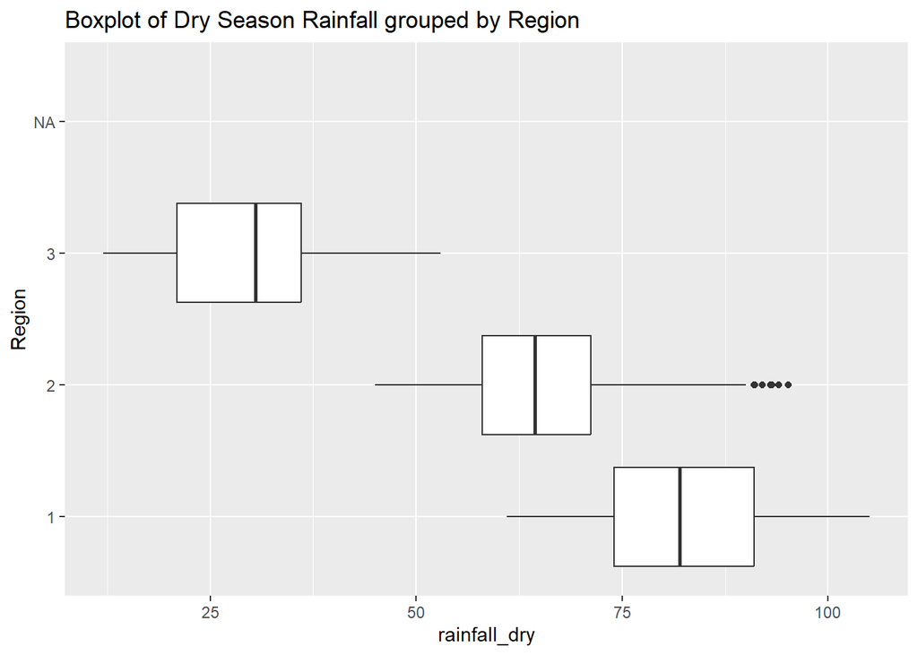

```r
g <- ggplot(data = survey_final_gis, aes(x = rainfall_dry, y = as.factor(studycode)))
g + geom_boxplot() + labs(title = "Boxplot of Dry Season Rainfall grouped by Region") +
  ylab("Region")
```

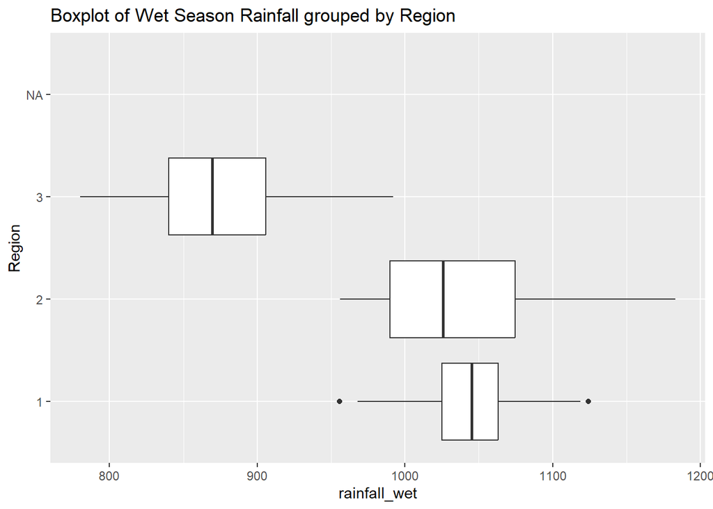

```r
g <- ggplot(data = survey_final_gis, aes(x = rainfall_wet, y = as.factor(studycode)))
g + geom_boxplot() + labs(title = "Boxplot of Wet Season Rainfall grouped by Region") +
  ylab("Region")
```

Next lets look at pair plots

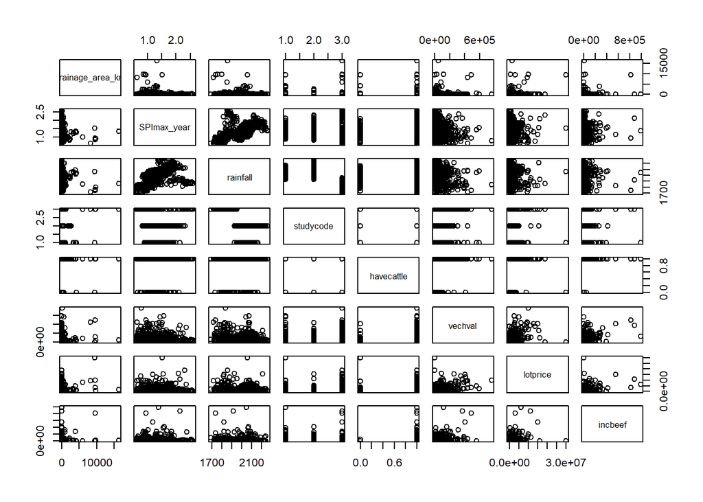

```r
pairs_subset <- survey_final_gis %>% select(c(drainage_area_km, SPImax_year, rainfall, studycode, havecattle, vechval, lotprice, incbeef))
pairs(pairs_subset)
```

Let’s look at how many households fall into each region

```r
table(survey_final_gis$studycode)
```

```
##
##   1   2   3
## 368 441 391
```

Let’s also look at some basic summary statistics

```r
describe(survey_final_gis[c('drainage_area_km', 'rainfall', 'rainfall_wet', 'rainfall_dry', 'SPI_wet', 'SPI_dry', 'incbeef', 'vechval', 'lotprice', 'family')], fast=TRUE)
```

```
##                  vars    n       mean         sd     min         max
## drainage_area_km    1 1340     126.10     846.22    0.01    16295.36
## rainfall            2 1200    1982.59     116.73 1693.00     2261.00
## rainfall_wet        3 1200     984.51      89.15  780.00     1183.00
## rainfall_dry        4 1200      59.03      24.22   12.00      105.00
## SPI_wet             5 1200       0.46       0.44   -0.58        1.13
## SPI_dry             6 1200       0.10       0.37   -0.96        0.62
## incbeef             7  698   27979.62   78088.34    0.00   990000.00
## vechval             8 1200   50514.90   74844.85    0.00   763000.00
## lotprice            9 1137 1315067.21 2034041.25 1000.00 30000000.00
## family             10 1200       3.75       2.18    0.00       15.00
##                        range       se
## drainage_area_km    16295.35    23.12
## rainfall              568.00     3.37
## rainfall_wet          403.00     2.57
## rainfall_dry           93.00     0.70
## SPI_wet                 1.70     0.01
## SPI_dry                 1.58     0.01
## incbeef            990000.00  2955.69
## vechval            763000.00  2160.58
## lotprice         29999000.00 60322.53
## family                 15.00     0.06
```

I’m curious about how many farms made multiple adaptations

```r
table(survey_final_gis$cattle_management, survey_final_gis$pasture_management)
```

```
##
##       0   1
##   0 467 373
##   1 110 390
```

```r
table(survey_final_gis$cattle_management, survey_final_gis$forest_conservation)
```

```
##
##       0   1
##   0 216 624
##   1  34 466
```

```r
table(survey_final_gis$cattle_management, survey_final_gis$water_management)
```

```
##
##       0   1
##   0 169 671
##   1  22 478
```

```r
table(survey_final_gis$pasture_management, survey_final_gis$forest_conservation)
```

```
##
##       0   1
##   0 194 383
##   1  56 707
```

```r
table(survey_final_gis$pasture_management, survey_final_gis$water_management)
```

```
##
##       0   1
##   0 162 415
##   1  29 734
```

```r
table(survey_final_gis$forest_conservation, survey_final_gis$water_management)
```

```
##
##        0    1
##   0  149  101
##   1   42 1048
```

It looks like the majority of farmers who adapted did more than one thing.

## boxplot supplement

### Effect of region on drainage area, rainfall and vechval

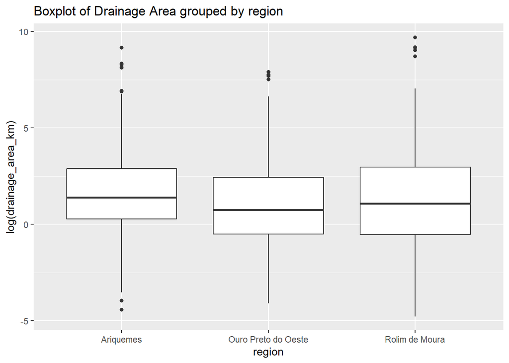

```r
g <- ggplot(data = survey_final_gis_clean, aes(y = log(drainage_area_km), x = as.factor(region)))
g + geom_boxplot() + labs(title = "Boxplot of Drainage Area grouped by region") +
  xlab("region")
```

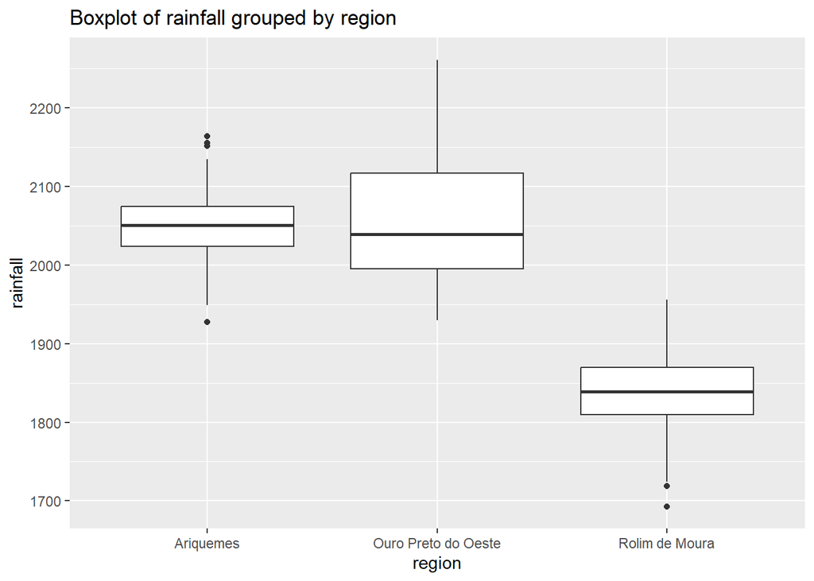

```r
g <- ggplot(data = survey_final_gis_clean, aes(y = rainfall, x= as.factor(region)))
g + geom_boxplot() + labs(title = "Boxplot of rainfall grouped by region") +
  xlab("region")
```

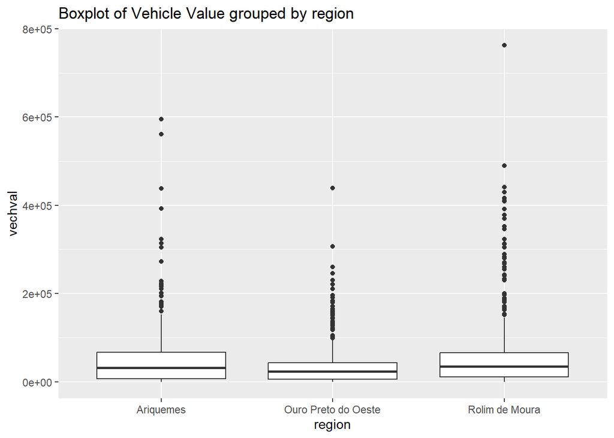

```r
g <- ggplot(data = survey_final_gis_clean, aes(y = vechval, x = as.factor(region)))
g + geom_boxplot() + labs(title = "Boxplot of Vehicle Value grouped by region") +
  xlab("region")
```

### Effect of cattle_management on drainage area, rainfall and vechval

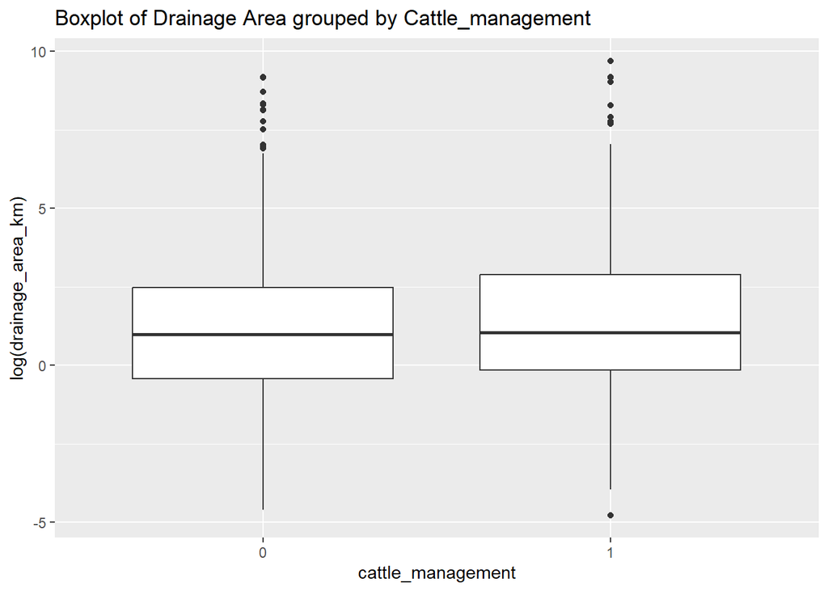

```r
g <- ggplot(data = survey_final_gis, aes(y = log(drainage_area_km), x = as.factor(cattle_management)))
g + geom_boxplot() + labs(title = "Boxplot of Drainage Area grouped by Cattle_management") +
  xlab("cattle_management")
```

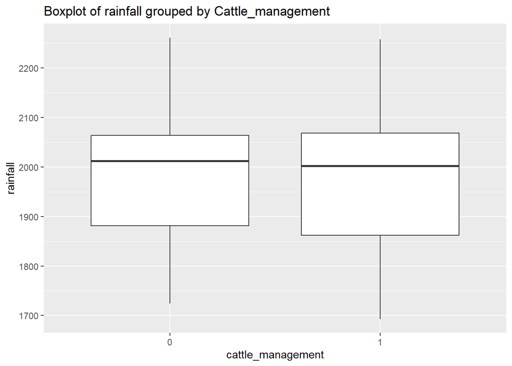

```r
g <- ggplot(data = survey_final_gis, aes(y = rainfall, x = as.factor(cattle_management)))
g + geom_boxplot() + labs(title = "Boxplot of rainfall grouped by Cattle_management") +
  xlab("cattle_management")
```

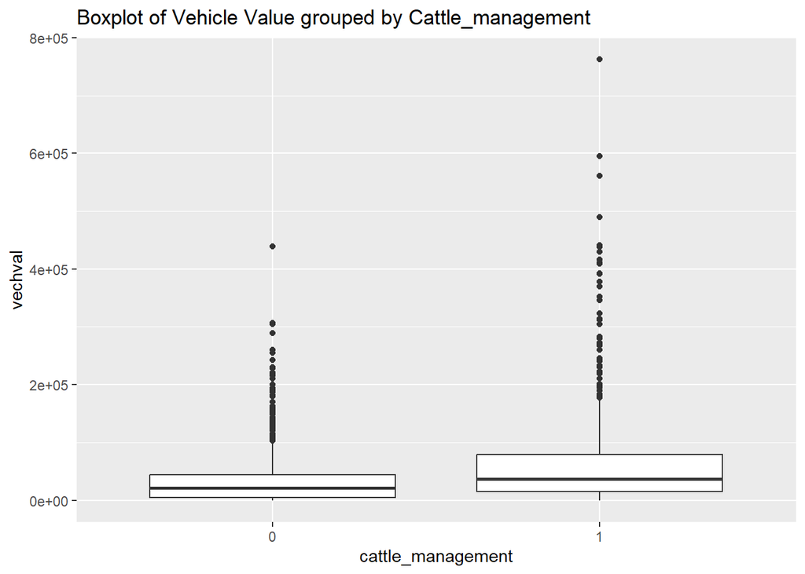

```r
g <- ggplot(data = survey_final_gis, aes(y = vechval, x = as.factor(cattle_management)))
g + geom_boxplot() + labs(title = "Boxplot of Vehicle Value grouped by Cattle_management") +
  xlab("cattle_management")
```

### Effect of pasture_management on drainage area, rainfall and vechval

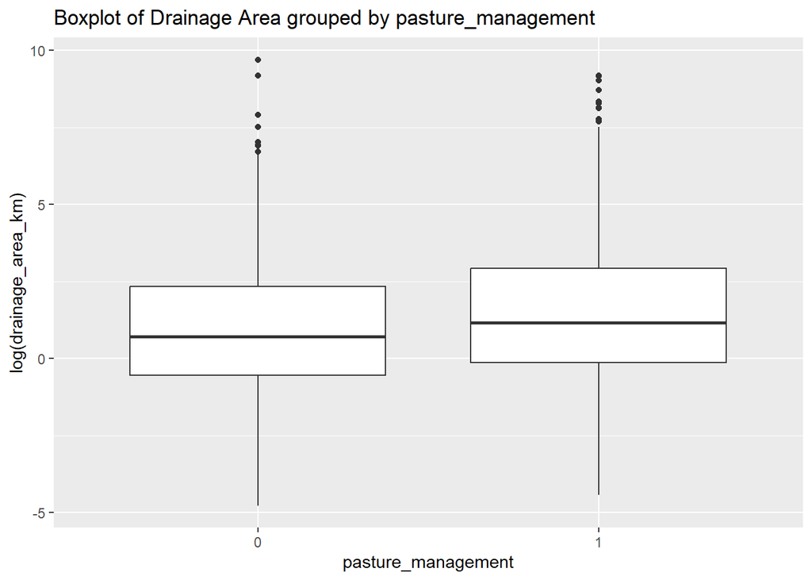

```r
g <- ggplot(data = survey_final_gis, aes(y = log(drainage_area_km), x = as.factor(pasture_management)))
g + geom_boxplot() + labs(title = "Boxplot of Drainage Area grouped by pasture_management") +
  xlab("pasture_management")
```

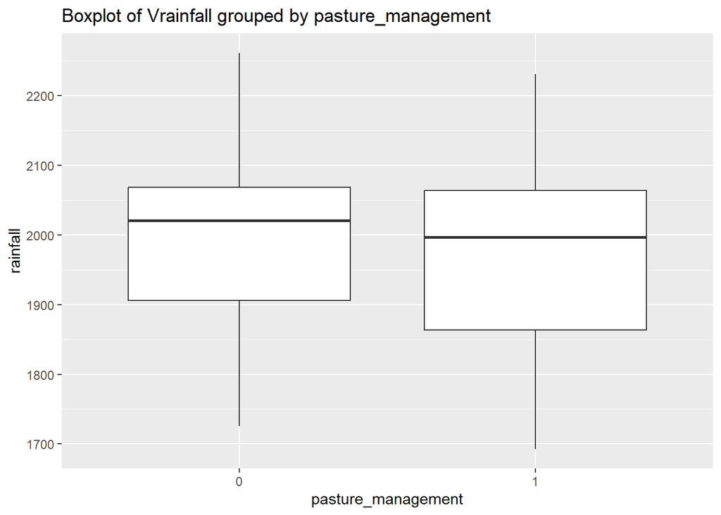

```r
g <- ggplot(data = survey_final_gis, aes(y = rainfall, x = as.factor(pasture_management)))
g + geom_boxplot() + labs(title = "Boxplot of Vrainfall grouped by pasture_management") +
  xlab("pasture_management")
```

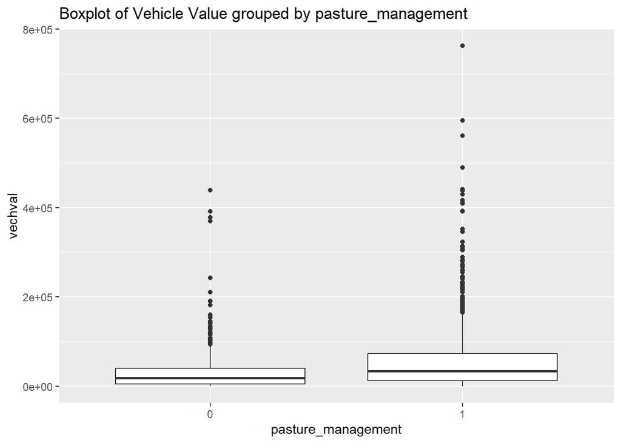

```r
g <- ggplot(data = survey_final_gis, aes(y = vechval, x = as.factor(pasture_management)))
g + geom_boxplot() + labs(title = "Boxplot of Vehicle Value grouped by pasture_management") +
  xlab("pasture_management")
```

### Effect of forest_conservation on drainage area, rainfall and vechval

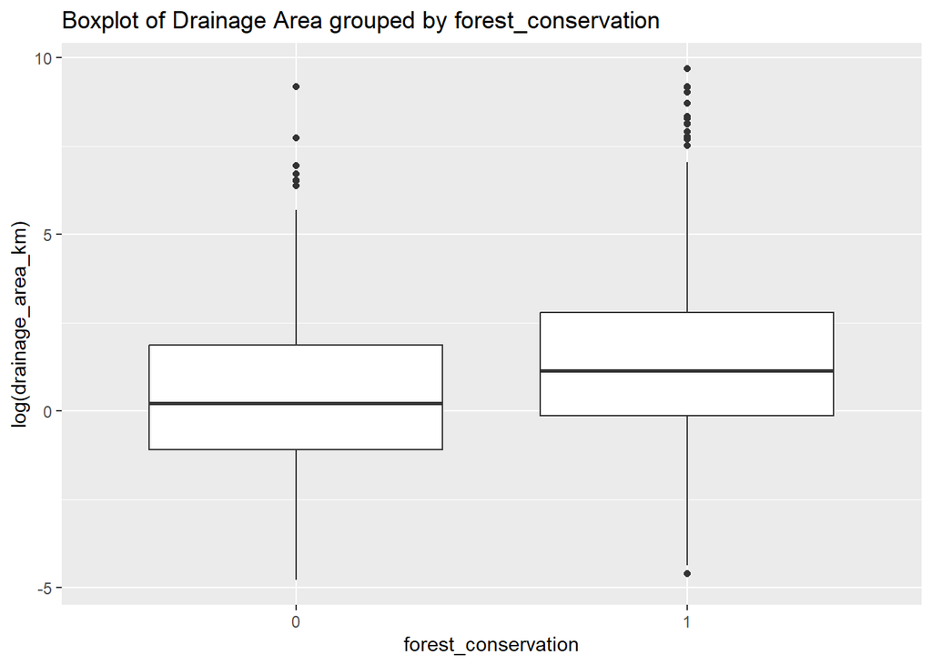

```r
g <- ggplot(data = survey_final_gis, aes(y = log(drainage_area_km), x = as.factor(forest_conservation)))
g + geom_boxplot() + labs(title = "Boxplot of Drainage Area grouped by forest_conservation") +
  xlab("forest_conservation")
```

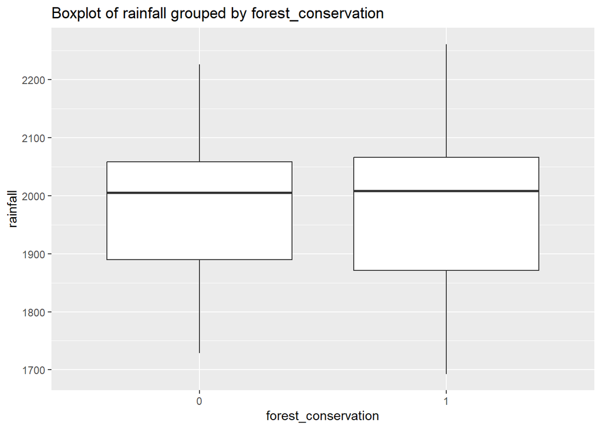

```r
g <- ggplot(data = survey_final_gis, aes(y = rainfall, x = as.factor(forest_conservation)))
g + geom_boxplot() + labs(title = "Boxplot of rainfall grouped by forest_conservation") +
  xlab("forest_conservation")
```

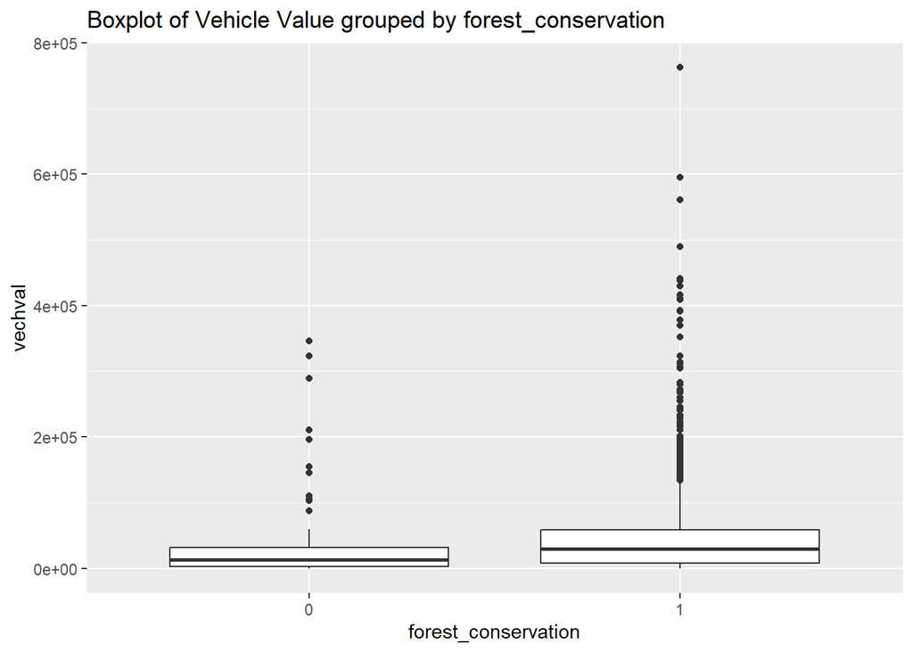

```r
g <- ggplot(data = survey_final_gis, aes(y = vechval, x = as.factor(forest_conservation)))
g + geom_boxplot() + labs(title = "Boxplot of Vehicle Value grouped by forest_conservation") +
  xlab("forest_conservation")
```

### Effect of water_management on drainage area, rainfall and vechval

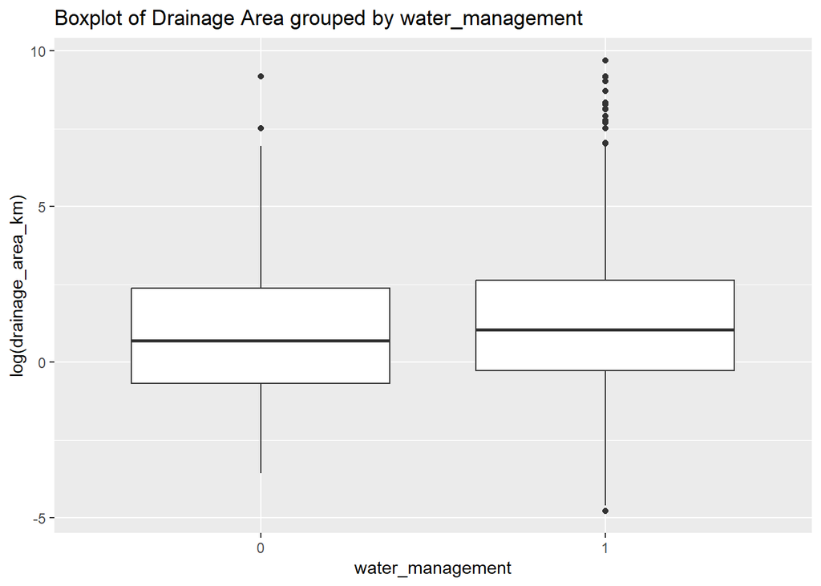

```r
g <- ggplot(data = survey_final_gis, aes(y = log(drainage_area_km), x = as.factor(water_management)))
g + geom_boxplot() + labs(title = "Boxplot of Drainage Area grouped by water_management") +
  xlab("water_management")
```

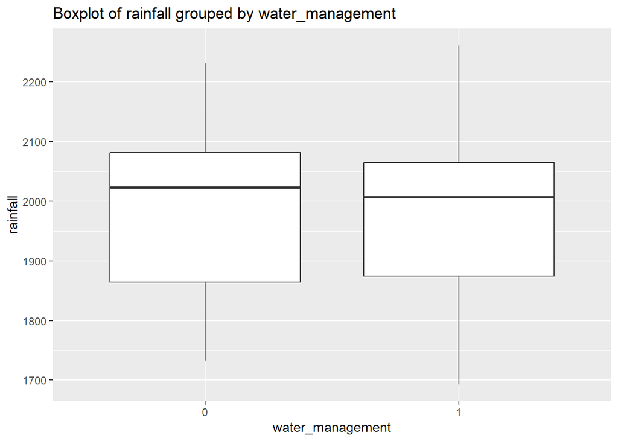

```r
g <- ggplot(data = survey_final_gis, aes(y = rainfall, x = as.factor(water_management)))
g + geom_boxplot() + labs(title = "Boxplot of rainfall grouped by water_management") +
  xlab("water_management")
```

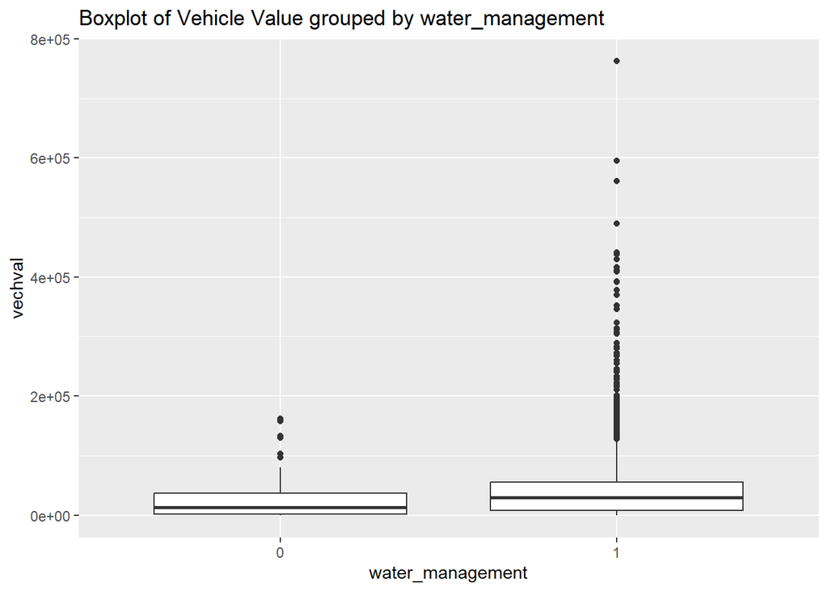

```r
g <- ggplot(data = survey_final_gis, aes(y = vechval, x = as.factor(water_management)))
g + geom_boxplot() + labs(title = "Boxplot of Vehicle Value grouped by water_management") +
  xlab("water_management")
```

### Effect of any_adaptation on drainage area, rainfall and vechval

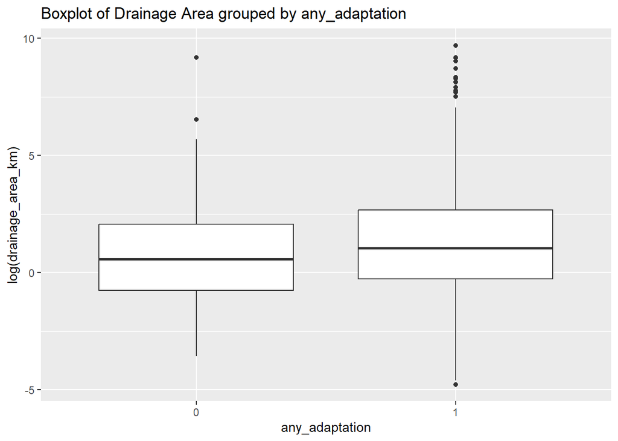

```r
g <- ggplot(data = survey_final_gis, aes(y = log(drainage_area_km), x = as.factor(any_adaptation)))
g + geom_boxplot() + labs(title = "Boxplot of Drainage Area grouped by any_adaptation") +
  xlab("any_adaptation")
```

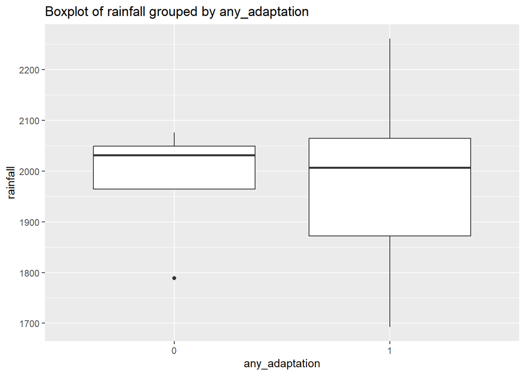

```r
g <- ggplot(data = survey_final_gis, aes(y = rainfall, x = as.factor(any_adaptation)))
g + geom_boxplot() + labs(title = "Boxplot of rainfall grouped by any_adaptation") +
  xlab("any_adaptation")
```

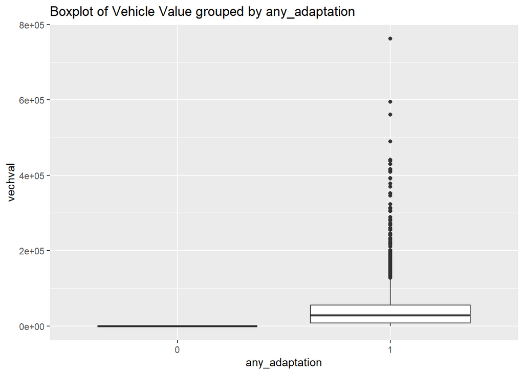

```r
g <- ggplot(data = survey_final_gis, aes(y = vechval, x = as.factor(any_adaptation)))
g + geom_boxplot() + labs(title = "Boxplot of Vehicle Value grouped by any_adaptation") +
  xlab("any_adaptation")
```

Boxplotx of milkincome, SPI and rainfall

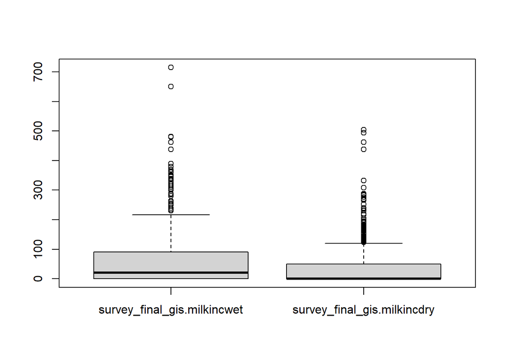

```r
milkcinc <- data.frame(survey_final_gis$milkincwet,survey_final_gis$milkincdry)
boxplot(milkcinc)
```

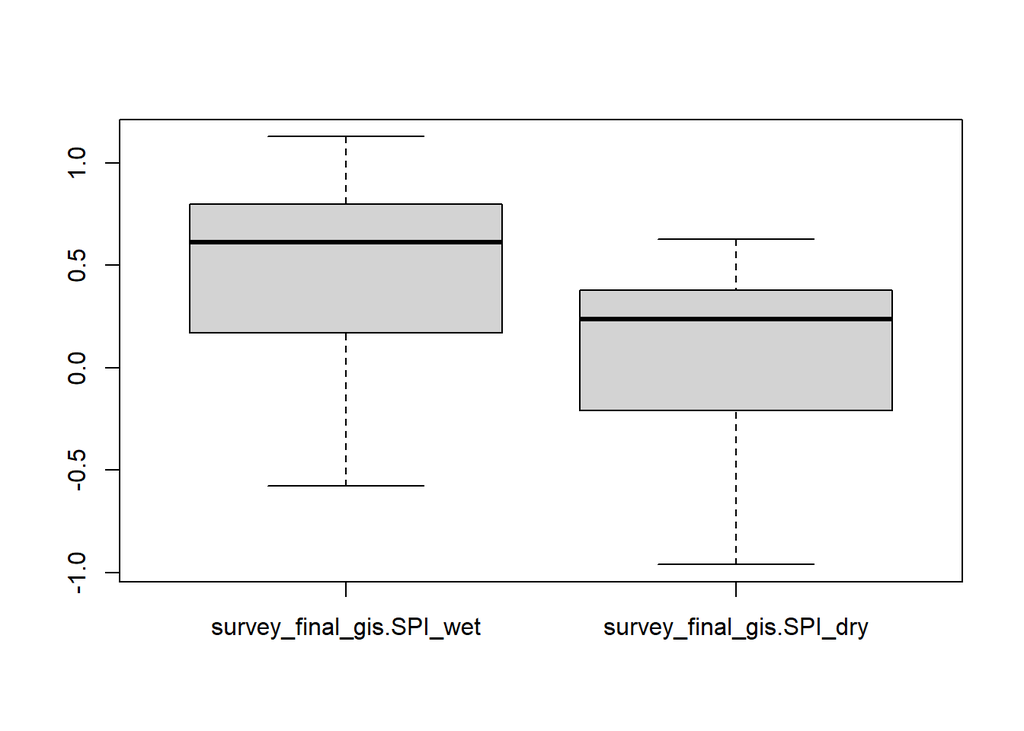

```r
SPI <- data.frame(survey_final_gis$SPI_wet,survey_final_gis$SPI_dry)
boxplot(SPI)
```

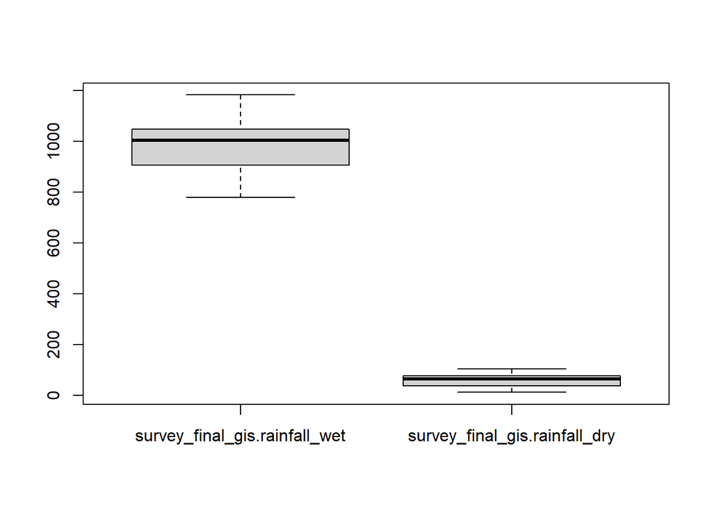

```r
rainfall <- data.frame(survey_final_gis$rainfall_wet,survey_final_gis$rainfall_dry)
boxplot(rainfall)
```

# Statisitcal analysis ## t test for drainage area

```r
quartiles_1 <- quantile(survey_final_gis[survey_final_gis$any_adaptation==1,]$drainage_area_km, probs=c(.25, .75), na.rm = TRUE)
IQR_1 <- IQR(survey_final_gis[survey_final_gis$any_adaptation==1,]$drainage_area_km,na.rm = TRUE)

Lower_1 <- quartiles_1[1] - 1.5*IQR_1
Upper_1 <- quartiles_1[2] + 1.5*IQR_1

data_no_outlier_1<- subset(survey_final_gis[survey_final_gis$any_adaptation==1,]$drainage_area_km, survey_final_gis[survey_final_gis$any_adaptation==1,]$drainage_area_km> Lower_1 & survey_final_gis[survey_final_gis$any_adaptation==1,]$drainage_area_km< Upper_1)

quartiles_0 <- quantile(survey_final_gis[survey_final_gis$any_adaptation==0,]$drainage_area_km, probs=c(.25, .75), na.rm = TRUE)
IQR_0 <- IQR(survey_final_gis[survey_final_gis$any_adaptation==0,]$drainage_area_km,na.rm = TRUE)

Lower_0 <- quartiles_0[1] - 1.5*IQR_0
Upper_0 <- quartiles_0[2] + 1.5*IQR_0

data_no_outlier_0 <- subset(survey_final_gis[survey_final_gis$any_adaptation==0,]$drainage_area_km, survey_final_gis[survey_final_gis$any_adaptation==0,]$drainage_area_km> Lower_0 & survey_final_gis[survey_final_gis$any_adaptation==0,]$drainage_area_km< Upper_0)

t.test(data_no_outlier_1 , data_no_outlier_0 ,na.rm=TRUE,var.equal = FALSE)
```

```
##
##  Welch Two Sample t-test
##
## data:  data_no_outlier_1 and data_no_outlier_0
## t = 6.5409, df = 290.15, p-value = 2.756e-10
## alternative hypothesis: true difference in means is not equal to 0
## 95 percent confidence interval:
##  1.751338 3.258946
## sample estimates:
## mean of x mean of y
##  5.080324  2.575182
```

## t test for rainfall

```r
quartiles_1 <- quantile(survey_final_gis[survey_final_gis$any_adaptation==1,]$rainfall, probs=c(.25, .75), na.rm = TRUE)
IQR_1 <- IQR(survey_final_gis[survey_final_gis$any_adaptation==1,]$rainfall,na.rm = TRUE)

Lower_1 <- quartiles_1[1] - 1.5*IQR_1
Upper_1 <- quartiles_1[2] + 1.5*IQR_1

data_no_outlier_1<- subset(survey_final_gis[survey_final_gis$any_adaptation==1,]$rainfall, survey_final_gis[survey_final_gis$any_adaptation==1,]$rainfall> Lower_1 & survey_final_gis[survey_final_gis$any_adaptation==1,]$rainfall< Upper_1)

quartiles_0 <- quantile(survey_final_gis[survey_final_gis$any_adaptation==0,]$rainfall, probs=c(.25, .75), na.rm = TRUE)
IQR_0 <- IQR(survey_final_gis[survey_final_gis$any_adaptation==0,]$rainfall,na.rm = TRUE)

Lower_0 <- quartiles_0[1] - 1.5*IQR_0
Upper_0 <- quartiles_0[2] + 1.5*IQR_0

data_no_outlier_0 <- subset(survey_final_gis[survey_final_gis$any_adaptation==0,]$rainfall, survey_final_gis[survey_final_gis$any_adaptation==0,]$rainfall> Lower_0 & survey_final_gis[survey_final_gis$any_adaptation==0,]$rainfall< Upper_0)

t.test(data_no_outlier_1 , data_no_outlier_0 ,na.rm=TRUE,var.equal = FALSE)
```

```
##
##  Welch Two Sample t-test
##
## data:  data_no_outlier_1 and data_no_outlier_0
## t = -3.9741, df = 2.1904, p-value = 0.04973
## alternative hypothesis: true difference in means is not equal to 0
## 95 percent confidence interval:
##  -127.0720236   -0.1718252
## sample estimates:
## mean of x mean of y
##  1982.589  2046.211
```

## t test for milkincome at different seasons

We would like to see if there is any difference of milkincome between dry and wet season. The null hypothesis is mean value of milkincome is the same for dry and wet season. H0: $\mu_{mlkinc,dry}=\mu_{mlkinc,wet)}$ vs Ha: $\mu_{mlkinc,dry} \ne \mu_{mlkinc,wet)}$

```r
t.test(survey_final_gis_clean$milkincwet,survey_final_gis_clean$milkincdry,na.rm=TRUE,var.equal = FALSE)
```

```
##
##  Welch Two Sample t-test
##
## data:  survey_final_gis_clean$milkincwet and survey_final_gis_clean$milkincdry
## t = 7.5306, df = 1816.9, p-value = 7.911e-14
## alternative hypothesis: true difference in means is not equal to 0
## 95 percent confidence interval:
##  18.16078 30.95159
## sample estimates:
## mean of x mean of y
##  57.62763  33.07144
```

As p is much less than 0.05, we are confident the mean value of milkincome of wetseason is significant higher than dry season.

## t-test for rainfall at different seasons

```r
t.test(survey_final_gis_clean$rainfall_wet,survey_final_gis_clean$rainfall_dry,na.rm=TRUE,var.equal = FALSE)
```

```
##
##  Welch Two Sample t-test
##
## data:  survey_final_gis_clean$rainfall_wet and survey_final_gis_clean$rainfall_dry
## t = 347.03, df = 1375.1, p-value < 2.2e-16
## alternative hypothesis: true difference in means is not equal to 0
## 95 percent confidence interval:
##  920.2497 930.7128
## sample estimates:
## mean of x mean of y
## 984.50655  59.02528
```

## t-test for SPI at different seasons

We would like to see if there is any difference in SPI between dry and wet season. The null hypothesis is mean value of SPI is the same for dry and wet season. H0: $\mu_{SPI,dry}=\mu_{SPI,wet)}$ vs Ha: $\mu_{SPI,dry} \ne \mu_{SPI,wet)}$

```r
t.test(survey_final_gis_clean$SPI_wet,survey_final_gis_clean$SPI_dry,na.rm=TRUE,var.equal = FALSE)
```

```
##
##  Welch Two Sample t-test
##
## data:  survey_final_gis_clean$SPI_wet and survey_final_gis_clean$SPI_dry
## t = 22.235, df = 2328.1, p-value < 2.2e-16
## alternative hypothesis: true difference in means is not equal to 0
## 95 percent confidence interval:
##  0.3328086 0.3971907
## sample estimates:
## mean of x mean of y
## 0.4610647 0.0960650
```

Average SPI and average monthly SPI in the peak of wet season is significantly higher than those of dry season.

## Anova analysis

We hypothesize drainage area of three regions may be different. We propose null hypothesis is drainage area means of three regions are the same. The alternativae hypothesis is drainage area means of three regions are different.

### effect of region on drainage_area_km

```r
survey_final_gis_clean$region<- factor(survey_final_gis_clean$region)
aov_drainage <- aov(log(drainage_area_km) ~ region, data=survey_final_gis)

summary(aov_drainage)
```

```
##               Df Sum Sq Mean Sq F value  Pr(>F)
## region         2     64   32.14   5.706 0.00342 **
## Residuals   1197   6742    5.63
## ---
## Signif. codes:  0 '***' 0.001 '**' 0.01 '*' 0.05 '.' 0.1 ' ' 1
## 140 observations deleted due to missingness
```

```r
TukeyHSD(aov_drainage, conf.level=.95)
```

```
##   Tukey multiple comparisons of means
##     95% family-wise confidence level
##
## Fit: aov(formula = log(drainage_area_km) ~ region, data = survey_final_gis)
##
## $region
##                                          diff         lwr        upr     p adj
## Ouro Preto do Oeste-Ariquemes      -0.5630356 -0.95623345 -0.1698377 0.0023152
## Rolim de Moura-Ariquemes           -0.2559672 -0.66043949  0.1485050 0.2984517
## Rolim de Moura-Ouro Preto do Oeste  0.3070683 -0.07977413  0.6939108 0.1500875
```

### effect of region on income from beef

We then wants to see if there is difference in income from beef at different regions.

```r
aov_incbeef <- aov(incbeef ~ region, data=survey_final_gis)
summary(aov_incbeef)
```

```
##              Df    Sum Sq   Mean Sq F value Pr(>F)
## region        2 1.371e+10 6.853e+09   1.124  0.325
## Residuals   695 4.236e+12 6.096e+09
## 642 observations deleted due to missingness
```

```r
TukeyHSD(aov_incbeef, conf.level=.95)
```

```
##   Tukey multiple comparisons of means
##     95% family-wise confidence level
##
## Fit: aov(formula = incbeef ~ region, data = survey_final_gis)
##
## $region
##                                          diff       lwr       upr     p adj
## Ouro Preto do Oeste-Ariquemes      -11239.618 -29238.61  6759.375 0.3076587
## Rolim de Moura-Ariquemes            -6577.226 -22674.83  9520.381 0.6026638
## Rolim de Moura-Ouro Preto do Oeste   4662.393 -13029.43 22354.211 0.8097785
```

As p value is larger than 0.05, we can not reject our hypothesis that the means of income from beef at different regions are the same.

### effect of region on rainfall

```r
aov_rainfall <- aov(rainfall~ region, data=survey_final_gis )
summary(aov_rainfall)
```

```
##               Df   Sum Sq Mean Sq F value Pr(>F)
## region         2 12088742 6044371    1703 <2e-16 ***
## Residuals   1197  4249056    3550
## ---
## Signif. codes:  0 '***' 0.001 '**' 0.01 '*' 0.05 '.' 0.1 ' ' 1
## 140 observations deleted due to missingness
```

```r
TukeyHSD(aov_rainfall, conf.level=.95)
```

```
##   Tukey multiple comparisons of means
##     95% family-wise confidence level
##
## Fit: aov(formula = rainfall ~ region, data = survey_final_gis)
##
## $region
##                                           diff         lwr        upr     p adj
## Ouro Preto do Oeste-Ariquemes         7.163234   -2.708057   17.03452 0.2045033
## Rolim de Moura-Ariquemes           -210.154234 -220.308569 -199.99990 0.0000000
## Rolim de Moura-Ouro Preto do Oeste -217.317468 -227.029204 -207.60573 0.0000000
```

As p-value for F test of AONVA is very small, rainfall in three regions is not the same. It can be seen the rainfall in region “Rolim de Moura” is less than that in the other two.

### effect of region on wealth

```r
aov_vechval <- aov(vechval~ region, data=survey_final_gis_clean)
summary(aov_vechval)
```

```
##               Df    Sum Sq   Mean Sq F value   Pr(>F)
## region         2 1.581e+11 7.907e+10   14.43 6.41e-07 ***
## Residuals   1197 6.558e+12 5.479e+09
## ---
## Signif. codes:  0 '***' 0.001 '**' 0.01 '*' 0.05 '.' 0.1 ' ' 1
```

```r
TukeyHSD(aov_vechval, conf.level=.95)
```

```
##   Tukey multiple comparisons of means
##     95% family-wise confidence level
##
## Fit: aov(formula = vechval ~ region, data = survey_final_gis_clean)
##
## $region
##                                         diff         lwr       upr     p adj
## Ouro Preto do Oeste-Ariquemes      -15301.14 -27564.9489 -3037.328 0.0097323
## Rolim de Moura-Ariquemes            12195.46   -420.0017 24810.912 0.0606958
## Rolim de Moura-Ouro Preto do Oeste  27496.59  15431.0086 39562.178 0.0000003
```

The family wealth is significant different in three regions. The wealth in region “3”Rolim de Moura” is the largest.

### Effect of region on adapatation method

Will need to do this for each method, since methods can overlap

First - cattle management

```r
# Need to change studycode into a factor
survey_final_gis$studycode <- as.factor(survey_final_gis$studycode)
aov_cattle_management <- aov(cattle_management ~ studycode, data = survey_final_gis)
summary(aov_cattle_management)
```

```
##               Df Sum Sq Mean Sq F value Pr(>F)
## studycode      2   0.99  0.4958   2.042   0.13
## Residuals   1197 290.68  0.2428
## 140 observations deleted due to missingness
```

Cattle management appears to be the same across all three regions based on the p-value

Next - water management

```r
aov_water_management <- aov(water_management ~ studycode, data = survey_final_gis)
summary(aov_water_management)
```

```
##               Df Sum Sq Mean Sq F value  Pr(>F)
## studycode      2   0.55 0.27330   6.775 0.00119 **
## Residuals   1197  48.29 0.04034
## ---
## Signif. codes:  0 '***' 0.001 '**' 0.01 '*' 0.05 '.' 0.1 ' ' 1
## 140 observations deleted due to missingness
```

```r
TukeyHSD(aov_water_management, conf.level=.95)
```

```
##   Tukey multiple comparisons of means
##     95% family-wise confidence level
##
## Fit: aov(formula = water_management ~ studycode, data = survey_final_gis)
##
## $studycode
##            diff         lwr          upr     p adj
## 2-1 -0.05217268 -0.08544920 -0.018896162 0.0007144
## 3-1 -0.02989130 -0.06412198  0.004339368 0.1011412
## 3-2  0.02228138 -0.01045728  0.055020031 0.2472685
```

Based on the p-value, we know at least two regions are signficantly different Using the results of Tukey’s HSD, we can see that regions 1 and 2 (Ariquemes and OPO) are significantly different when it comes to water management

Next - pasture management

```r
aov_pasture_management <- aov(pasture_management ~ studycode, data = survey_final_gis)
summary(aov_pasture_management)
```

```
##               Df Sum Sq Mean Sq F value   Pr(>F)
## studycode      2   3.81  1.9064   8.327 0.000256 ***
## Residuals   1197 274.05  0.2289
## ---
## Signif. codes:  0 '***' 0.001 '**' 0.01 '*' 0.05 '.' 0.1 ' ' 1
## 140 observations deleted due to missingness
```

```r
TukeyHSD(aov_pasture_management, conf.level=.95)
```

```
##   Tukey multiple comparisons of means
##     95% family-wise confidence level
##
## Fit: aov(formula = pasture_management ~ studycode, data = survey_final_gis)
##
## $studycode
##            diff         lwr          upr     p adj
## 2-1 -0.08256310 -0.16183872 -0.003287472 0.0389323
## 3-1  0.05131074 -0.03023799  0.132859475 0.3025965
## 3-2  0.13387384  0.05587959  0.211868094 0.0001767
```

From the result of the ANOVA, we can see there is a difference between at least one region. Looking at the result of Tukey, we can see the difference is significant between regions 1 and 2, and regions 2 and 3

Next - forest conservation

```r
aov_forest_conservation <- aov(forest_conservation ~ studycode, data = survey_final_gis)
summary(aov_forest_conservation)
```

```
##               Df Sum Sq Mean Sq F value Pr(>F)
## studycode      2   0.33  0.1644   1.976  0.139
## Residuals   1197  99.59  0.0832
## 140 observations deleted due to missingness
```

```r
#TukeyHSD(aov_pasture_management, conf.level=.95)
```

There is not a significant difference amongst regions due to forest conservation

### Effect of wealth on number of adaptations

```r
survey_final_gis <- survey_final_gis %>% mutate(adaptation_count = cattle_management + pasture_management + water_management + forest_conservation)
aov_vechval_adaptation_count <- aov(vechval ~ adaptation_count, data = survey_final_gis)
summary(aov_vechval_adaptation_count)
```

```
##                    Df    Sum Sq   Mean Sq F value Pr(>F)
## adaptation_count    1 4.354e+11 4.354e+11   83.05 <2e-16 ***
## Residuals        1198 6.281e+12 5.243e+09
## ---
## Signif. codes:  0 '***' 0.001 '**' 0.01 '*' 0.05 '.' 0.1 ' ' 1
## 140 observations deleted due to missingness
```

```r
fit_lr <- lm(adaptation_count ~ vechval, data = survey_final_gis)
summary(fit_lr)
```

```
##
## Call:
## lm(formula = adaptation_count ~ vechval, data = survey_final_gis)
##
## Residuals:
##     Min      1Q  Median      3Q     Max
## -2.7671 -0.7821  0.1191  0.8003  1.2329
##
## Coefficients:
##              Estimate Std. Error t value Pr(>|t|)
## (Intercept) 2.767e+00  2.965e-02  93.340   <2e-16 ***
## vechval     2.993e-06  3.284e-07   9.113   <2e-16 ***
## ---
## Signif. codes:  0 '***' 0.001 '**' 0.01 '*' 0.05 '.' 0.1 ' ' 1
##
## Residual standard error: 0.8511 on 1198 degrees of freedom
##   (140 observations deleted due to missingness)
## Multiple R-squared:  0.06483,    Adjusted R-squared:  0.06405
## F-statistic: 83.05 on 1 and 1198 DF,  p-value: < 2.2e-16
```

# Modelling

## Multiple Logistic Regression Model

First to create a few different MLRs to see what the relationship is between adaptation methods and water availability.

### Model 1

In this model, I will select the largest amount of variables. The dependent variable will be the general adaptation variable. The independent variables will be: - Drainage area - Lot size (can’t find in data - ask Mariana) - Soil type (100% missing - so maybe not) - Vehicle value - SPI - using the maximum in the year - Risk - Lot value

(This model did not converge)

### Model 2

Trying with only drainage area to see if there’s a relationship since previous model did not converge

```r
fit_2 <- glm(any_adaptation ~ drainage_area_km, family = binomial,data = survey_final_gis)
summary(fit_2)
```

```
##
## Call:
## glm(formula = any_adaptation ~ drainage_area_km, family = binomial,
##     data = survey_final_gis)
##
## Coefficients:
##                   Estimate Std. Error z value Pr(>|z|)
## (Intercept)      2.1088684  0.0891751   23.65   <2e-16 ***
## drainage_area_km 0.0000746  0.0001408    0.53    0.596
## ---
## Signif. codes:  0 '***' 0.001 '**' 0.01 '*' 0.05 '.' 0.1 ' ' 1
##
## (Dispersion parameter for binomial family taken to be 1)
##
##     Null deviance: 914.36  on 1339  degrees of freedom
## Residual deviance: 914.01  on 1338  degrees of freedom
## AIC: 918.01
##
## Number of Fisher Scoring iterations: 5
```

The drainage area is not a statistically significant parameter in this case. However, there are outliers in the data that might be affecting this. Let’s investigate.

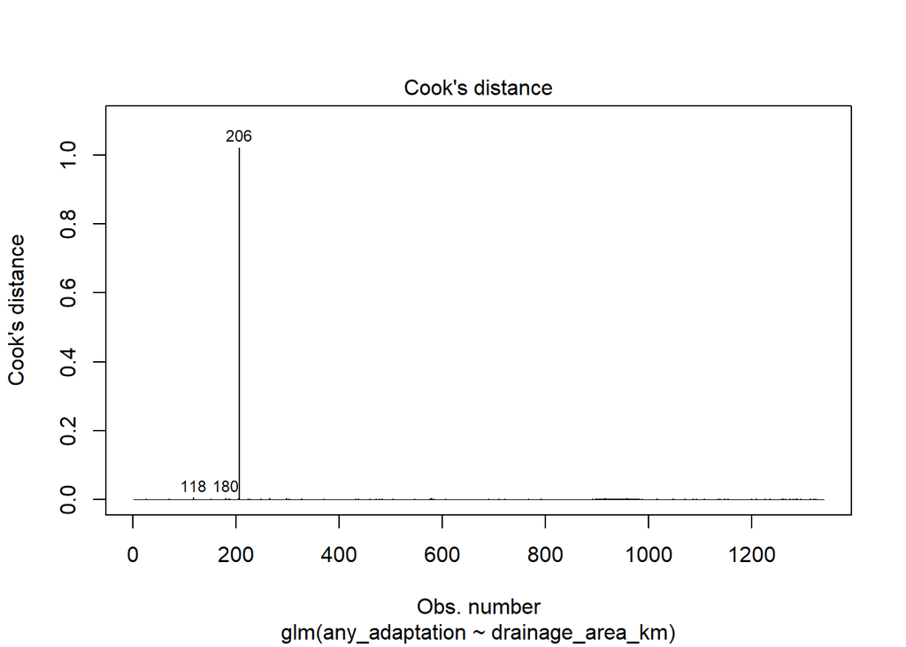

```r
plot(fit_2, which = 4)
```

Fitting the model without observation 206

```r
survey_final_gis_no <- survey_final_gis[-c(206),]
fit_3 <- glm(any_adaptation ~ drainage_area_km, family = binomial,data = survey_final_gis_no)
summary(fit_3)
```

```
##
## Call:
## glm(formula = any_adaptation ~ drainage_area_km, family = binomial,
##     data = survey_final_gis_no)
##
## Coefficients:
##                   Estimate Std. Error z value Pr(>|z|)
## (Intercept)      2.0599143  0.0913975  22.538   <2e-16 ***
## drainage_area_km 0.0015679  0.0009512   1.648   0.0993 .
## ---
## Signif. codes:  0 '***' 0.001 '**' 0.01 '*' 0.05 '.' 0.1 ' ' 1
##
## (Dispersion parameter for binomial family taken to be 1)
##
##     Null deviance: 909.89  on 1338  degrees of freedom
## Residual deviance: 902.26  on 1337  degrees of freedom
## AIC: 906.26
##
## Number of Fisher Scoring iterations: 8
```

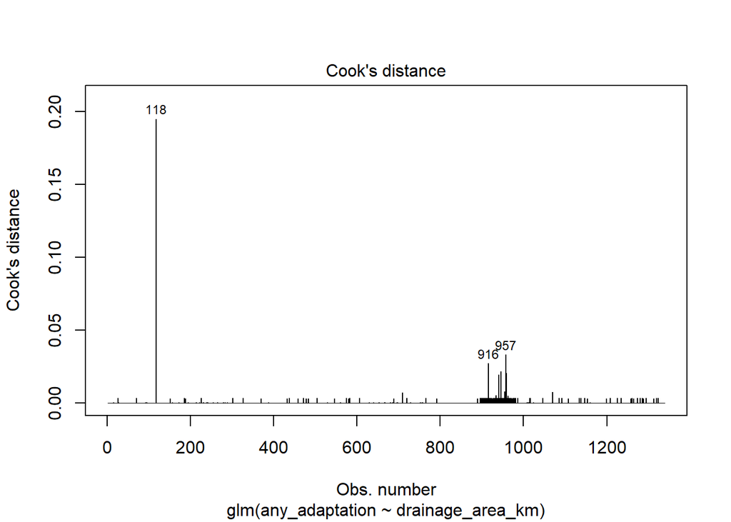

```r
plot(fit_3, which = 4)
```

Now to check Log Reg assumptions

```r
probabilities <- predict(fit_3, type = "response")
# Select only numeric predictors
mydata <- survey_final_gis_no %>%
  dplyr::select_if(is.numeric) %>%
  select(drainage_area_km)
predictors <- colnames(mydata)
# Bind the logit and tidying the data for plot
mydata <- mydata %>%
  mutate(logit = log(probabilities/(1-probabilities))) %>%
  gather(key = "predictors", value = "predictor.value", -logit)
```

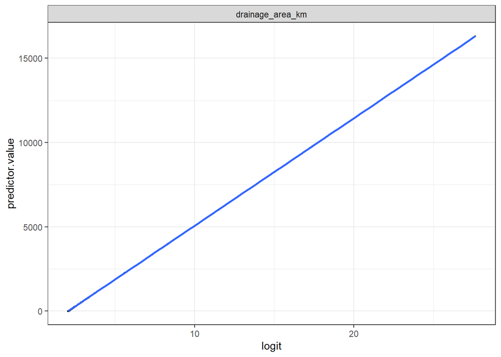

```r
ggplot(mydata, aes(logit, predictor.value))+
  geom_point(size = 0.5, alpha = 0.5) +
  geom_smooth(method = "loess") +
  theme_bw() +
  facet_wrap(~predictors, scales = "free_y")
```

### Model 3 - Transforming Drainage Area

Let’s look at the distribution of drainage area to see if we should transform it

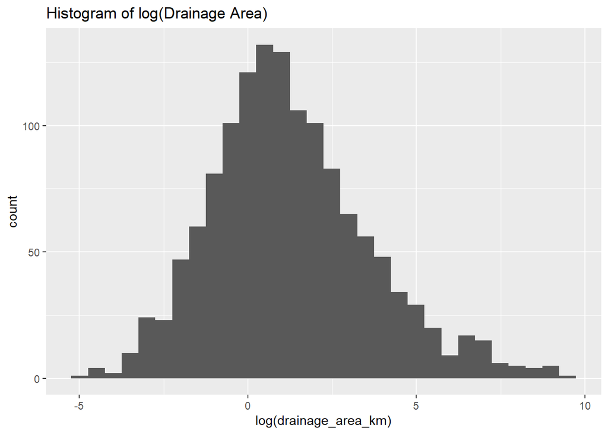

```r
g <- ggplot(data = survey_final_gis_no, aes(x = log(drainage_area_km)))
g + geom_histogram() + labs(title = "Histogram of log(Drainage Area)")
```

Now to create the model:

```r
fit_transform <- glm(any_adaptation ~ log(drainage_area_km), family = binomial,data = survey_final_gis)
summary(fit_transform)
```

```
##
## Call:
## glm(formula = any_adaptation ~ log(drainage_area_km), family = binomial,
##     data = survey_final_gis)
##
## Coefficients:
##                       Estimate Std. Error z value Pr(>|z|)
## (Intercept)            2.00718    0.09431  21.282  < 2e-16 ***
## log(drainage_area_km)  0.10519    0.03962   2.655  0.00792 **
## ---
## Signif. codes:  0 '***' 0.001 '**' 0.01 '*' 0.05 '.' 0.1 ' ' 1
##
## (Dispersion parameter for binomial family taken to be 1)
##
##     Null deviance: 914.36  on 1339  degrees of freedom
## Residual deviance: 906.98  on 1338  degrees of freedom
## AIC: 910.98
##
## Number of Fisher Scoring iterations: 5
```

### Model 4

First going to see the fit with outliers chopped off

```r
survey_final_gis_filtered <- survey_final_gis %>% filter(drainage_area_km < 500)
fit_4 <- glm(any_adaptation ~ drainage_area_km, data = survey_final_gis_filtered, family = binomial)
summary(fit_4)
```

```
##
## Call:
## glm(formula = any_adaptation ~ drainage_area_km, family = binomial,
##     data = survey_final_gis_filtered)
##
## Coefficients:
##                   Estimate Std. Error z value Pr(>|z|)
## (Intercept)      2.0771756  0.0949895  21.867   <2e-16 ***
## drainage_area_km 0.0004578  0.0018537   0.247    0.805
## ---
## Signif. codes:  0 '***' 0.001 '**' 0.01 '*' 0.05 '.' 0.1 ' ' 1
##
## (Dispersion parameter for binomial family taken to be 1)
##
##     Null deviance: 893.26  on 1284  degrees of freedom
## Residual deviance: 893.20  on 1283  degrees of freedom
## AIC: 897.2
##
## Number of Fisher Scoring iterations: 4
```

### model 5

```r
 survey_final_gis2<- drop_na(survey_final_gis,SPI_year)
survey_final_gis2$rainfall2 <- scale(survey_final_gis2$rainfall,center=TRUE,scale=T)
survey_final_gis2$drainage_area_km2 <-  scale(survey_final_gis2$drainage_area_km,center=TRUE,scale=T)
fit_3 <- glm(any_adaptation ~ log (drainage_area_km) + log(rainfall), family = binomial,data = survey_final_gis2)
summary(fit_3)
```

```
##
## Call:
## glm(formula = any_adaptation ~ log(drainage_area_km) + log(rainfall),
##     family = binomial, data = survey_final_gis2)
##
## Coefficients:
##                       Estimate Std. Error z value Pr(>|z|)
## (Intercept)             9.5080    63.5680   0.150    0.881
## log(drainage_area_km)  -0.1858     0.1883  -0.987    0.324
## log(rainfall)          -0.4552     8.3677  -0.054    0.957
##
## (Dispersion parameter for binomial family taken to be 1)
##
##     Null deviance: 53.617  on 1199  degrees of freedom
## Residual deviance: 52.706  on 1197  degrees of freedom
## AIC: 58.706
##
## Number of Fisher Scoring iterations: 8
```

Now look at individual adaptation variables

```r
fit_cattle <- glm(cattle_management ~ drainage_area_km, family = binomial,data = survey_final_gis)
summary(fit_cattle)
```

```
##
## Call:
## glm(formula = cattle_management ~ drainage_area_km, family = binomial,
##     data = survey_final_gis)
##
## Coefficients:
##                    Estimate Std. Error z value Pr(>|z|)
## (Intercept)      -5.298e-01  5.717e-02  -9.267   <2e-16 ***
## drainage_area_km  8.492e-05  6.657e-05   1.276    0.202
## ---
## Signif. codes:  0 '***' 0.001 '**' 0.01 '*' 0.05 '.' 0.1 ' ' 1
##
## (Dispersion parameter for binomial family taken to be 1)
##
##     Null deviance: 1770.4  on 1339  degrees of freedom
## Residual deviance: 1768.7  on 1338  degrees of freedom
## AIC: 1772.7
##
## Number of Fisher Scoring iterations: 4
```

```r
fit_cattle_log = glm(cattle_management ~ log(drainage_area_km), family = binomial,data = survey_final_gis)
summary(fit_cattle_log)
```

```
##
## Call:
## glm(formula = cattle_management ~ log(drainage_area_km), family = binomial,
##     data = survey_final_gis)
##
## Coefficients:
##                       Estimate Std. Error z value Pr(>|z|)
## (Intercept)           -0.58609    0.06488  -9.033   <2e-16 ***
## log(drainage_area_km)  0.05162    0.02374   2.174   0.0297 *
## ---
## Signif. codes:  0 '***' 0.001 '**' 0.01 '*' 0.05 '.' 0.1 ' ' 1
##
## (Dispersion parameter for binomial family taken to be 1)
##
##     Null deviance: 1770.4  on 1339  degrees of freedom
## Residual deviance: 1765.7  on 1338  degrees of freedom
## AIC: 1769.7
##
## Number of Fisher Scoring iterations: 4
```

Saw significance when using log(drainage area)

Next lets look at pasture management

```r
fit_pasture <- glm(pasture_management ~ drainage_area_km, family = binomial,data = survey_final_gis)
summary(fit_pasture)
```

```
##
## Call:
## glm(formula = pasture_management ~ drainage_area_km, family = binomial,
##     data = survey_final_gis)
##
## Coefficients:
##                   Estimate Std. Error z value Pr(>|z|)
## (Intercept)      2.674e-01  5.583e-02   4.790 1.66e-06 ***
## drainage_area_km 1.028e-04  7.926e-05   1.296    0.195
## ---
## Signif. codes:  0 '***' 0.001 '**' 0.01 '*' 0.05 '.' 0.1 ' ' 1
##
## (Dispersion parameter for binomial family taken to be 1)
##
##     Null deviance: 1831.7  on 1339  degrees of freedom
## Residual deviance: 1829.7  on 1338  degrees of freedom
## AIC: 1833.7
##
## Number of Fisher Scoring iterations: 4
```

```r
fit_pasture_log <- glm(pasture_management ~ log(drainage_area_km), family = binomial,data = survey_final_gis)
summary(fit_pasture_log)
```

```
##
## Call:
## glm(formula = pasture_management ~ log(drainage_area_km), family = binomial,
##     data = survey_final_gis)
##
## Coefficients:
##                       Estimate Std. Error z value Pr(>|z|)
## (Intercept)            0.16275    0.06229   2.613  0.00898 **
## log(drainage_area_km)  0.09512    0.02396   3.971 7.17e-05 ***
## ---
## Signif. codes:  0 '***' 0.001 '**' 0.01 '*' 0.05 '.' 0.1 ' ' 1
##
## (Dispersion parameter for binomial family taken to be 1)
##
##     Null deviance: 1831.7  on 1339  degrees of freedom
## Residual deviance: 1815.5  on 1338  degrees of freedom
## AIC: 1819.5
##
## Number of Fisher Scoring iterations: 4
```

Similar results, but with a super low p for log(drainage area)

Next lets look at forest conservation

```r
fit_forest <- glm(forest_conservation ~ drainage_area_km, family = binomial,data = survey_final_gis)
summary(fit_forest)
```

```
##
## Call:
## glm(formula = forest_conservation ~ drainage_area_km, family = binomial,
##     data = survey_final_gis)
##
## Coefficients:
##                   Estimate Std. Error z value Pr(>|z|)
## (Intercept)      1.4593884  0.0709507  20.569   <2e-16 ***
## drainage_area_km 0.0001294  0.0001311   0.987    0.324
## ---
## Signif. codes:  0 '***' 0.001 '**' 0.01 '*' 0.05 '.' 0.1 ' ' 1
##
## (Dispersion parameter for binomial family taken to be 1)
##
##     Null deviance: 1289.6  on 1339  degrees of freedom
## Residual deviance: 1288.3  on 1338  degrees of freedom
## AIC: 1292.3
##
## Number of Fisher Scoring iterations: 5
```

```r
fit_forest_log <- glm(forest_conservation ~ log(drainage_area_km), family = binomial,data = survey_final_gis)
summary(fit_forest_log)
```

```
##
## Call:
## glm(formula = forest_conservation ~ log(drainage_area_km), family = binomial,
##     data = survey_final_gis)
##
## Coefficients:
##                       Estimate Std. Error z value Pr(>|z|)
## (Intercept)            1.30277    0.07451  17.485  < 2e-16 ***
## log(drainage_area_km)  0.17455    0.03290   5.305 1.12e-07 ***
## ---
## Signif. codes:  0 '***' 0.001 '**' 0.01 '*' 0.05 '.' 0.1 ' ' 1
##
## (Dispersion parameter for binomial family taken to be 1)
##
##     Null deviance: 1289.6  on 1339  degrees of freedom
## Residual deviance: 1259.1  on 1338  degrees of freedom
## AIC: 1263.1
##
## Number of Fisher Scoring iterations: 4
```

Log(drainage area) is highly significant again

Let’s now look at water management

```r
fit_water <- glm(water_management ~ drainage_area_km, family = binomial,data = survey_final_gis)
summary(fit_water)
```

```
##
## Call:
## glm(formula = water_management ~ drainage_area_km, family = binomial,
##     data = survey_final_gis)
##
## Coefficients:
##                   Estimate Std. Error z value Pr(>|z|)
## (Intercept)      1.785e+00  7.901e-02  22.598   <2e-16 ***
## drainage_area_km 8.384e-05  1.268e-04   0.661    0.509
## ---
## Signif. codes:  0 '***' 0.001 '**' 0.01 '*' 0.05 '.' 0.1 ' ' 1
##
## (Dispersion parameter for binomial family taken to be 1)
##
##     Null deviance: 1097.6  on 1339  degrees of freedom
## Residual deviance: 1097.0  on 1338  degrees of freedom
## AIC: 1101
##
## Number of Fisher Scoring iterations: 4
```

```r
fit_water_log <- glm(water_management ~ log(drainage_area_km), family = binomial,data = survey_final_gis)
summary(fit_water_log)
```

```
##
## Call:
## glm(formula = water_management ~ log(drainage_area_km), family = binomial,
##     data = survey_final_gis)
##
## Coefficients:
##                       Estimate Std. Error z value Pr(>|z|)
## (Intercept)            1.71958    0.08552  20.108   <2e-16 ***
## log(drainage_area_km)  0.06572    0.03416   1.924   0.0543 .
## ---
## Signif. codes:  0 '***' 0.001 '**' 0.01 '*' 0.05 '.' 0.1 ' ' 1
##
## (Dispersion parameter for binomial family taken to be 1)
##
##     Null deviance: 1097.6  on 1339  degrees of freedom
## Residual deviance: 1093.8  on 1338  degrees of freedom
## AIC: 1097.8
##
## Number of Fisher Scoring iterations: 4
```

What happens if I filter by “have cattle” and look at cattle_management

```r
survey_havecattle <-survey_final_gis %>% filter(havecattle ==1)
fit_cattle_have <- glm(cattle_management ~ drainage_area_km, family = binomial,data = survey_havecattle)
summary(fit_cattle_have)
```

```
##
## Call:
## glm(formula = cattle_management ~ drainage_area_km, family = binomial,
##     data = survey_havecattle)
##
## Coefficients:
##                    Estimate Std. Error z value Pr(>|z|)
## (Intercept)      -1.137e-01  6.405e-02  -1.775   0.0759 .
## drainage_area_km  1.082e-04  8.377e-05   1.291   0.1966
## ---
## Signif. codes:  0 '***' 0.001 '**' 0.01 '*' 0.05 '.' 0.1 ' ' 1
##
## (Dispersion parameter for binomial family taken to be 1)
##
##     Null deviance: 1389.3  on 1003  degrees of freedom
## Residual deviance: 1387.4  on 1002  degrees of freedom
## AIC: 1391.4
##
## Number of Fisher Scoring iterations: 3
```

```r
fit_cattle_have_log <- glm(cattle_management ~ log(drainage_area_km), family = binomial,data = survey_havecattle)
summary(fit_cattle_have_log)
```

```
##
## Call:
## glm(formula = cattle_management ~ log(drainage_area_km), family = binomial,
##     data = survey_havecattle)
##
## Coefficients:
##                       Estimate Std. Error z value Pr(>|z|)
## (Intercept)           -0.13422    0.07437  -1.805   0.0711 .
## log(drainage_area_km)  0.02411    0.02729   0.883   0.3770
## ---
## Signif. codes:  0 '***' 0.001 '**' 0.01 '*' 0.05 '.' 0.1 ' ' 1
##
## (Dispersion parameter for binomial family taken to be 1)
##
##     Null deviance: 1389.3  on 1003  degrees of freedom
## Residual deviance: 1388.6  on 1002  degrees of freedom
## AIC: 1392.6
##
## Number of Fisher Scoring iterations: 3
```

Interesting, if we only include those that have cattle, the significance of the log(drainage area) disappears.

Let’s see if anything similar happens when filtered by havecattle for any of the other adaptations

```r
fit_pasture_have_log <- glm(pasture_management ~ log(drainage_area_km), family = binomial,data = survey_havecattle)
summary(fit_pasture_have_log)
```

```
##
## Call:
## glm(formula = pasture_management ~ log(drainage_area_km), family = binomial,
##     data = survey_havecattle)
##
## Coefficients:
##                       Estimate Std. Error z value Pr(>|z|)
## (Intercept)            0.76591    0.07953   9.630   <2e-16 ***
## log(drainage_area_km)  0.07154    0.03075   2.327     0.02 *
## ---
## Signif. codes:  0 '***' 0.001 '**' 0.01 '*' 0.05 '.' 0.1 ' ' 1
##
## (Dispersion parameter for binomial family taken to be 1)
##
##     Null deviance: 1221.1  on 1003  degrees of freedom
## Residual deviance: 1215.6  on 1002  degrees of freedom
## AIC: 1219.6
##
## Number of Fisher Scoring iterations: 4
```

```r
fit_forest_have_log <- glm(forest_conservation ~ log(drainage_area_km), family = binomial,data = survey_havecattle)
summary(fit_forest_have_log)
```

```
##
## Call:
## glm(formula = forest_conservation ~ log(drainage_area_km), family = binomial,
##     data = survey_havecattle)
##
## Coefficients:
##                       Estimate Std. Error z value Pr(>|z|)
## (Intercept)            2.22569    0.12126  18.354  < 2e-16 ***
## log(drainage_area_km)  0.26151    0.06041   4.329  1.5e-05 ***
## ---
## Signif. codes:  0 '***' 0.001 '**' 0.01 '*' 0.05 '.' 0.1 ' ' 1
##
## (Dispersion parameter for binomial family taken to be 1)
##
##     Null deviance: 553.3  on 1003  degrees of freedom
## Residual deviance: 532.1  on 1002  degrees of freedom
## AIC: 536.1
##
## Number of Fisher Scoring iterations: 6
```

```r
fit_water_have_log <- glm(water_management ~ log(drainage_area_km), family = binomial,data = survey_havecattle)
summary(fit_forest_have_log)
```

```
##
## Call:
## glm(formula = forest_conservation ~ log(drainage_area_km), family = binomial,
##     data = survey_havecattle)
##
## Coefficients:
##                       Estimate Std. Error z value Pr(>|z|)
## (Intercept)            2.22569    0.12126  18.354  < 2e-16 ***
## log(drainage_area_km)  0.26151    0.06041   4.329  1.5e-05 ***
## ---
## Signif. codes:  0 '***' 0.001 '**' 0.01 '*' 0.05 '.' 0.1 ' ' 1
##
## (Dispersion parameter for binomial family taken to be 1)
##
##     Null deviance: 553.3  on 1003  degrees of freedom
## Residual deviance: 532.1  on 1002  degrees of freedom
## AIC: 536.1
##
## Number of Fisher Scoring iterations: 6
```

I’m curious about how many farms made multiple adaptations

```r
table(survey_final_gis$cattle_management, survey_final_gis$pasture_management)
```

```
##
##       0   1
##   0 467 373
##   1 110 390
```

```r
table(survey_final_gis$cattle_management, survey_final_gis$forest_conservation)
```

```
##
##       0   1
##   0 216 624
##   1  34 466
```

```r
table(survey_final_gis$cattle_management, survey_final_gis$water_management)
```

```
##
##       0   1
##   0 169 671
##   1  22 478
```

```r
table(survey_final_gis$pasture_management, survey_final_gis$forest_conservation)
```

```
##
##       0   1
##   0 194 383
##   1  56 707
```

```r
table(survey_final_gis$pasture_management, survey_final_gis$water_management)
```

```
##
##       0   1
##   0 162 415
##   1  29 734
```

```r
table(survey_final_gis$forest_conservation, survey_final_gis$water_management)
```

```
##
##        0    1
##   0  149  101
##   1   42 1048
```

It looks like the majority of farmers who adapted did more than one thing.

Let’s also look at deforestation as a linear model

```r
fit_deforest <- lm(cleared_area ~ drainage_area_km, data = survey_final_gis)
summary(fit_deforest)
```

```
##
## Call:
## lm(formula = cleared_area ~ drainage_area_km, data = survey_final_gis)
##
## Residuals:
##     Min      1Q  Median      3Q     Max
## -375.73  -55.97  -34.22    6.90 2102.51
##
## Coefficients:
##                   Estimate Std. Error t value Pr(>|t|)
## (Intercept)      75.319662   4.286540  17.571  < 2e-16 ***
## drainage_area_km  0.033203   0.004989   6.655 4.29e-11 ***
## ---
## Signif. codes:  0 '***' 0.001 '**' 0.01 '*' 0.05 '.' 0.1 ' ' 1
##
## Residual standard error: 146.6 on 1195 degrees of freedom
##   (143 observations deleted due to missingness)
## Multiple R-squared:  0.03574,    Adjusted R-squared:  0.03493
## F-statistic: 44.29 on 1 and 1195 DF,  p-value: 4.295e-11
```

```r
fit_deforest_log <- lm(cleared_area ~ log(drainage_area_km), data = survey_final_gis)
summary(fit_deforest_log)
```

```
##
## Call:
## lm(formula = cleared_area ~ log(drainage_area_km), data = survey_final_gis)
##
## Residuals:
##     Min      1Q  Median      3Q     Max
## -172.64  -52.52  -24.31    7.40 2093.49
##
## Coefficients:
##                       Estimate Std. Error t value Pr(>|t|)
## (Intercept)             59.849      4.797  12.475   <2e-16 ***
## log(drainage_area_km)   14.910      1.759   8.477   <2e-16 ***
## ---
## Signif. codes:  0 '***' 0.001 '**' 0.01 '*' 0.05 '.' 0.1 ' ' 1
##
## Residual standard error: 145 on 1195 degrees of freedom
##   (143 observations deleted due to missingness)
## Multiple R-squared:  0.05672,    Adjusted R-squared:  0.05594
## F-statistic: 71.86 on 1 and 1195 DF,  p-value: < 2.2e-16
```

We see significance for both the drainage area and the log(drainage area). Both had positive coefficients, which is confusing if my understanding of drainage_area and cleared_area are both correct.

```r
survey_final_gis_wealth <- survey_final_gis %>% filter(!is.na(survey_final_gis$vechval))
fit_wealth_ldrain_water <- glm(water_management~  vechval + log(drainage_area_km), family = binomial, data = survey_final_gis_wealth )
fit_wealth_ldrain_cattle  <- glm(cattle_management~  vechval + log(drainage_area_km) , family = binomial, data = survey_final_gis_wealth )
fit_wealth_ldrain_pasture  <- glm(pasture_management~  vechval + log(drainage_area_km), family = binomial, data = survey_final_gis_wealth )
fit_wealth_ldrain_forest <- glm(forest_conservation~  vechval + log(drainage_area_km), family = binomial, data = survey_final_gis_wealth )
#fit_wealth_drainn_any_adaptation <- glm(any_adaptation~  vechval + log(drainage_area_km), family = binomial, data = survey_final_gis_wealth )
summary(fit_wealth_ldrain_water)
```

```
##
## Call:
## glm(formula = water_management ~ vechval + log(drainage_area_km),
##     family = binomial, data = survey_final_gis_wealth)
##
## Coefficients:
##                         Estimate Std. Error z value Pr(>|z|)
## (Intercept)            2.921e+00  1.999e-01  14.616   <2e-16 ***
## vechval                7.799e-06  3.710e-06   2.102   0.0355 *
## log(drainage_area_km) -7.259e-02  5.769e-02  -1.258   0.2083
## ---
## Signif. codes:  0 '***' 0.001 '**' 0.01 '*' 0.05 '.' 0.1 ' ' 1
##
## (Dispersion parameter for binomial family taken to be 1)
##
##     Null deviance: 421.94  on 1199  degrees of freedom
## Residual deviance: 414.38  on 1197  degrees of freedom
## AIC: 420.38
##
## Number of Fisher Scoring iterations: 7
```

```r
summary(fit_wealth_ldrain_cattle)
```

```
##
## Call:
## glm(formula = cattle_management ~ vechval + log(drainage_area_km),
##     family = binomial, data = survey_final_gis_wealth)
##
## Coefficients:
##                         Estimate Std. Error z value Pr(>|z|)
## (Intercept)           -6.776e-01  8.061e-02  -8.407  < 2e-16 ***
## vechval                6.768e-06  1.014e-06   6.672 2.52e-11 ***
## log(drainage_area_km)  4.919e-03  2.559e-02   0.192    0.848
## ---
## Signif. codes:  0 '***' 0.001 '**' 0.01 '*' 0.05 '.' 0.1 ' ' 1
##
## (Dispersion parameter for binomial family taken to be 1)
##
##     Null deviance: 1630.1  on 1199  degrees of freedom
## Residual deviance: 1571.4  on 1197  degrees of freedom
## AIC: 1577.4
##
## Number of Fisher Scoring iterations: 4
```

```r
summary(fit_wealth_ldrain_pasture)
```

```
##
## Call:
## glm(formula = pasture_management ~ vechval + log(drainage_area_km),
##     family = binomial, data = survey_final_gis_wealth)
##
## Coefficients:
##                        Estimate Std. Error z value Pr(>|z|)
## (Intercept)           1.764e-01  8.196e-02   2.152   0.0314 *
## vechval               7.178e-06  1.293e-06   5.553 2.81e-08 ***
## log(drainage_area_km) 5.432e-02  2.627e-02   2.068   0.0387 *
## ---
## Signif. codes:  0 '***' 0.001 '**' 0.01 '*' 0.05 '.' 0.1 ' ' 1
##
## (Dispersion parameter for binomial family taken to be 1)
##
##     Null deviance: 1573.9  on 1199  degrees of freedom
## Residual deviance: 1521.6  on 1197  degrees of freedom
## AIC: 1527.6
##
## Number of Fisher Scoring iterations: 4
```

```r
summary(fit_wealth_ldrain_forest)
```

```
##
## Call:
## glm(formula = forest_conservation ~ vechval + log(drainage_area_km),
##     family = binomial, data = survey_final_gis_wealth)
##
## Coefficients:
##                        Estimate Std. Error z value Pr(>|z|)
## (Intercept)           1.938e+00  1.266e-01  15.313  < 2e-16 ***
## vechval               4.393e-06  2.241e-06   1.960     0.05 *
## log(drainage_area_km) 2.058e-01  4.851e-02   4.242 2.22e-05 ***
## ---
## Signif. codes:  0 '***' 0.001 '**' 0.01 '*' 0.05 '.' 0.1 ' ' 1
##
## (Dispersion parameter for binomial family taken to be 1)
##
##     Null deviance: 735.30  on 1199  degrees of freedom
## Residual deviance: 706.36  on 1197  degrees of freedom
## AIC: 712.36
##
## Number of Fisher Scoring iterations: 6
```

```r
#summary(fit_wealth_drain_any_adaptation )
```

The model for any adaptation did not converge, but all of the others did. Vehicle value was still significant for all of the adaptation measures. Log(drainage area) was not significant for water or cattle management when vehicle value is included, but it is for pasture management and forest conservation. For forest conservation, drainage area has a much smaller p value than vehicle value.

Try using draianage area with the tail chopped off instead of log transform

```r
survey_final_gis_wealth_filtered <- survey_final_gis_wealth %>% filter(drainage_area_km < 500)
fit_wealth_drain_water <- glm(water_management~  vechval + drainage_area_km, family = binomial, data = survey_final_gis_wealth_filtered )
fit_wealth_drain_cattle  <- glm(cattle_management~  vechval + drainage_area_km , family = binomial, data = survey_final_gis_wealth_filtered )
fit_wealth_drain_pasture  <- glm(pasture_management~  vechval + drainage_area_km, family = binomial, data = survey_final_gis_wealth_filtered )
fit_wealth_drain_forest <- glm(forest_conservation~  vechval + drainage_area_km, family = binomial, data = survey_final_gis_wealth_filtered )
#fit_wealth_drainn_any_adaptation <- glm(any_adaptation~  vechval + drainage_area_km, family = binomial, data = survey_final_gis_wealth_filtered )
summary(fit_wealth_drain_water)
```

```
##
## Call:
## glm(formula = water_management ~ vechval + drainage_area_km,
##     family = binomial, data = survey_final_gis_wealth_filtered)
##
## Coefficients:
##                    Estimate Std. Error z value Pr(>|z|)
## (Intercept)       2.881e+00  1.920e-01  15.004   <2e-16 ***
## vechval           6.662e-06  3.628e-06   1.836   0.0663 .
## drainage_area_km -1.470e-03  2.511e-03  -0.586   0.5582
## ---
## Signif. codes:  0 '***' 0.001 '**' 0.01 '*' 0.05 '.' 0.1 ' ' 1
##
## (Dispersion parameter for binomial family taken to be 1)
##
##     Null deviance: 404.88  on 1146  degrees of freedom
## Residual deviance: 399.83  on 1144  degrees of freedom
## AIC: 405.83
##
## Number of Fisher Scoring iterations: 6
```

```r
summary(fit_wealth_drain_cattle)
```

```
##
## Call:
## glm(formula = cattle_management ~ vechval + drainage_area_km,
##     family = binomial, data = survey_final_gis_wealth_filtered)
##
## Coefficients:
##                    Estimate Std. Error z value Pr(>|z|)
## (Intercept)      -6.819e-01  8.071e-02  -8.449  < 2e-16 ***
## vechval           6.748e-06  1.044e-06   6.463 1.03e-10 ***
## drainage_area_km  1.257e-04  1.212e-03   0.104    0.917
## ---
## Signif. codes:  0 '***' 0.001 '**' 0.01 '*' 0.05 '.' 0.1 ' ' 1
##
## (Dispersion parameter for binomial family taken to be 1)
##
##     Null deviance: 1555.4  on 1146  degrees of freedom
## Residual deviance: 1503.0  on 1144  degrees of freedom
## AIC: 1509
##
## Number of Fisher Scoring iterations: 4
```

```r
summary(fit_wealth_drain_pasture)
```

```
##
## Call:
## glm(formula = pasture_management ~ vechval + drainage_area_km,
##     family = binomial, data = survey_final_gis_wealth_filtered)
##
## Coefficients:
##                   Estimate Std. Error z value Pr(>|z|)
## (Intercept)      2.298e-01  8.193e-02   2.804  0.00504 **
## vechval          7.084e-06  1.300e-06   5.449 5.07e-08 ***
## drainage_area_km 2.042e-04  1.251e-03   0.163  0.87040
## ---
## Signif. codes:  0 '***' 0.001 '**' 0.01 '*' 0.05 '.' 0.1 ' ' 1
##
## (Dispersion parameter for binomial family taken to be 1)
##
##     Null deviance: 1509.1  on 1146  degrees of freedom
## Residual deviance: 1468.3  on 1144  degrees of freedom
## AIC: 1474.3
##
## Number of Fisher Scoring iterations: 4
```

```r
summary(fit_wealth_drain_forest)
```

```
##
## Call:
## glm(formula = forest_conservation ~ vechval + drainage_area_km,
##     family = binomial, data = survey_final_gis_wealth_filtered)
##
## Coefficients:
##                   Estimate Std. Error z value Pr(>|z|)
## (Intercept)      1.958e+00  1.345e-01  14.557   <2e-16 ***
## vechval          5.166e-06  2.287e-06   2.259   0.0239 *
## drainage_area_km 1.018e-02  4.895e-03   2.080   0.0376 *
## ---
## Signif. codes:  0 '***' 0.001 '**' 0.01 '*' 0.05 '.' 0.1 ' ' 1
##
## (Dispersion parameter for binomial family taken to be 1)
##
##     Null deviance: 702.18  on 1146  degrees of freedom
## Residual deviance: 686.66  on 1144  degrees of freedom
## AIC: 692.66
##
## Number of Fisher Scoring iterations: 6
```

```r
#summary(fit_wealth_drain_any_adaptation )
```

With the drainage area outliers removed, drainage area is significant for forest conservation but none of the others.

```r
rainfall_group<- cut(survey_final_gis_wealth_filtered$rainfall , c(0,1950,2300), label=c("low","high"))
rainfall_group <-factor(rainfall_group)
survey_final_gis_wealth_filtered$studycode <-factor(survey_final_gis_wealth_filtered$studycode)
fit_wealth_drain_water <- glm(water_management~  vechval + drainage_area_km, family = binomial, data = survey_final_gis_wealth_filtered )
fit_wealth_drain_cattle  <- glm(cattle_management~  vechval + drainage_area_km, family = binomial, data = survey_final_gis_wealth_filtered )
fit_wealth_drain_pasture  <- glm(pasture_management~  vechval + drainage_area_km, family = binomial, data = survey_final_gis_wealth_filtered )
fit_wealth_drain_forest <- glm(forest_conservation~  vechval + log(drainage_area_km) + log(rainfall_year) + studycode, family = binomial, data = survey_final_gis_wealth_filtered )
#fit_wealth_drainn_any_adaptation <- glm(any_adaptation~  vechval + drainage_area_km, family = binomial, data = survey_final_gis_wealth_filtered )
summary(fit_wealth_drain_water)
```

```
##
## Call:
## glm(formula = water_management ~ vechval + drainage_area_km,
##     family = binomial, data = survey_final_gis_wealth_filtered)
##
## Coefficients:
##                    Estimate Std. Error z value Pr(>|z|)
## (Intercept)       2.881e+00  1.920e-01  15.004   <2e-16 ***
## vechval           6.662e-06  3.628e-06   1.836   0.0663 .
## drainage_area_km -1.470e-03  2.511e-03  -0.586   0.5582
## ---
## Signif. codes:  0 '***' 0.001 '**' 0.01 '*' 0.05 '.' 0.1 ' ' 1
##
## (Dispersion parameter for binomial family taken to be 1)
##
##     Null deviance: 404.88  on 1146  degrees of freedom
## Residual deviance: 399.83  on 1144  degrees of freedom
## AIC: 405.83
##
## Number of Fisher Scoring iterations: 6
```

```r
summary(fit_wealth_drain_cattle)
```

```
##
## Call:
## glm(formula = cattle_management ~ vechval + drainage_area_km,
##     family = binomial, data = survey_final_gis_wealth_filtered)
##
## Coefficients:
##                    Estimate Std. Error z value Pr(>|z|)
## (Intercept)      -6.819e-01  8.071e-02  -8.449  < 2e-16 ***
## vechval           6.748e-06  1.044e-06   6.463 1.03e-10 ***
## drainage_area_km  1.257e-04  1.212e-03   0.104    0.917
## ---
## Signif. codes:  0 '***' 0.001 '**' 0.01 '*' 0.05 '.' 0.1 ' ' 1
##
## (Dispersion parameter for binomial family taken to be 1)
##
##     Null deviance: 1555.4  on 1146  degrees of freedom
## Residual deviance: 1503.0  on 1144  degrees of freedom
## AIC: 1509
##
## Number of Fisher Scoring iterations: 4
```

```r
summary(fit_wealth_drain_pasture)
```

```
##
## Call:
## glm(formula = pasture_management ~ vechval + drainage_area_km,
##     family = binomial, data = survey_final_gis_wealth_filtered)
##
## Coefficients:
##                   Estimate Std. Error z value Pr(>|z|)
## (Intercept)      2.298e-01  8.193e-02   2.804  0.00504 **
## vechval          7.084e-06  1.300e-06   5.449 5.07e-08 ***
## drainage_area_km 2.042e-04  1.251e-03   0.163  0.87040
## ---
## Signif. codes:  0 '***' 0.001 '**' 0.01 '*' 0.05 '.' 0.1 ' ' 1
##
## (Dispersion parameter for binomial family taken to be 1)
##
##     Null deviance: 1509.1  on 1146  degrees of freedom
## Residual deviance: 1468.3  on 1144  degrees of freedom
## AIC: 1474.3
##
## Number of Fisher Scoring iterations: 4
```

```r
summary(fit_wealth_drain_forest)
```

```
##
## Call:
## glm(formula = forest_conservation ~ vechval + log(drainage_area_km) +
##     log(rainfall_year) + studycode, family = binomial, data = survey_final_gis_wealth_filtered)
##
## Coefficients:
##                         Estimate Std. Error z value Pr(>|z|)
## (Intercept)            6.459e+00  3.104e+01   0.208    0.835
## vechval                3.364e-06  2.276e-06   1.478    0.139
## log(drainage_area_km)  2.767e-01  5.549e-02   4.987 6.14e-07 ***
## log(rainfall_year)    -5.694e-01  4.011e+00  -0.142    0.887
## studycode2            -2.466e-01  3.167e-01  -0.779    0.436
## studycode3             4.268e-02  6.275e-01   0.068    0.946
## ---
## Signif. codes:  0 '***' 0.001 '**' 0.01 '*' 0.05 '.' 0.1 ' ' 1
##
## (Dispersion parameter for binomial family taken to be 1)
##
##     Null deviance: 702.18  on 1146  degrees of freedom
## Residual deviance: 665.23  on 1141  degrees of freedom
## AIC: 677.23
##
## Number of Fisher Scoring iterations: 6
```

```r
#summary(fit_wealth_drain_any_adaptation )
```

Since we’ve seen that wealth is so important for adaptation, but drainage area importance decreases for wealth, let’s see if other water availability proxies are signficant for the individual adaptations

```r
fit_cattle_full <- glm(cattle_management ~ SPImax_year + vechval, family = binomial,data = survey_final_gis)
summary(fit_cattle)
```

```
##
## Call:
## glm(formula = cattle_management ~ drainage_area_km, family = binomial,
##     data = survey_final_gis)
##
## Coefficients:
##                    Estimate Std. Error z value Pr(>|z|)
## (Intercept)      -5.298e-01  5.717e-02  -9.267   <2e-16 ***
## drainage_area_km  8.492e-05  6.657e-05   1.276    0.202
## ---
## Signif. codes:  0 '***' 0.001 '**' 0.01 '*' 0.05 '.' 0.1 ' ' 1
##
## (Dispersion parameter for binomial family taken to be 1)
##
##     Null deviance: 1770.4  on 1339  degrees of freedom
## Residual deviance: 1768.7  on 1338  degrees of freedom
## AIC: 1772.7
##
## Number of Fisher Scoring iterations: 4
```

```r
fit_water_full <- glm(water_management ~ SPImax_year + vechval, family = binomial,data = survey_final_gis)
summary(fit_water_full)
```

```
##
## Call:
## glm(formula = water_management ~ SPImax_year + vechval, family = binomial,
##     data = survey_final_gis)
##
## Coefficients:
##               Estimate Std. Error z value Pr(>|z|)
## (Intercept)  4.223e+00  5.507e-01   7.669 1.73e-14 ***
## SPImax_year -9.839e-01  3.508e-01  -2.805  0.00503 **
## vechval      7.471e-06  3.777e-06   1.978  0.04792 *
## ---
## Signif. codes:  0 '***' 0.001 '**' 0.01 '*' 0.05 '.' 0.1 ' ' 1
##
## (Dispersion parameter for binomial family taken to be 1)
##
##     Null deviance: 421.94  on 1199  degrees of freedom
## Residual deviance: 408.44  on 1197  degrees of freedom
##   (140 observations deleted due to missingness)
## AIC: 414.44
##
## Number of Fisher Scoring iterations: 7
```

```r
fit_pasture_full <- glm(pasture_management ~ rainfall+ vechval, family = binomial,data = survey_final_gis)
summary(fit_pasture_full)
```

```
##
## Call:
## glm(formula = pasture_management ~ rainfall + vechval, family = binomial,
##     data = survey_final_gis)
##
## Coefficients:
##               Estimate Std. Error z value Pr(>|z|)
## (Intercept)  2.909e+00  1.071e+00   2.715  0.00663 **
## rainfall    -1.345e-03  5.365e-04  -2.507  0.01217 *
## vechval      7.361e-06  1.299e-06   5.668 1.45e-08 ***
## ---
## Signif. codes:  0 '***' 0.001 '**' 0.01 '*' 0.05 '.' 0.1 ' ' 1
##
## (Dispersion parameter for binomial family taken to be 1)
##
##     Null deviance: 1573.9  on 1199  degrees of freedom
## Residual deviance: 1519.6  on 1197  degrees of freedom
##   (140 observations deleted due to missingness)
## AIC: 1525.6
##
## Number of Fisher Scoring iterations: 4
```

```r
fit_forest_full <- glm(forest_conservation ~ SPImin_year + vechval, family = binomial,data = survey_final_gis)
summary(fit_forest_full)
```

```
##
## Call:
## glm(formula = forest_conservation ~ SPImin_year + vechval, family = binomial,
##     data = survey_final_gis)
##
## Coefficients:
##               Estimate Std. Error z value Pr(>|z|)
## (Intercept)  1.165e+00  4.268e-01   2.729  0.00634 **
## SPImin_year -8.688e-01  4.047e-01  -2.147  0.03183 *
## vechval      5.614e-06  2.248e-06   2.497  0.01252 *
## ---
## Signif. codes:  0 '***' 0.001 '**' 0.01 '*' 0.05 '.' 0.1 ' ' 1
##
## (Dispersion parameter for binomial family taken to be 1)
##
##     Null deviance: 735.30  on 1199  degrees of freedom
## Residual deviance: 721.45  on 1197  degrees of freedom
##   (140 observations deleted due to missingness)
## AIC: 727.45
##
## Number of Fisher Scoring iterations: 6
```